# Notebooks

## 3. Application in Finite Element Analysis

The materials defined are used in a finite element model, in which 3 different sections are assigned to the 3 different materials. This model is subjected to a unixial tensile stress in vertical direction, and the mechanical response of the model is analyzed in terms of total strain, plastic strain, and stress. All lengths are given in units of 1 mm.

```
2-d Model: uniaxial stress, isostrain condition
-----------------------------------------------
Global total strain: (eps_xx, eps_yy) = (-0.001,  0.002)
Local total strain (elements in different sections, Voigt tensor):
[-0.001  0.002 -0.001  0.     0.     0.   ]  in Section 1, Material: isotropic, ideal plastic
[-0.001  0.002 -0.001  0.     0.    -0.   ]  in Section 2, Material: low work-hardening
[-0.001  0.002 -0.001  0.     0.    -0.   ]  in Section 3, Material: strong work-hardening
Total strain in vertical direction: isostrain condition fulfilled
```

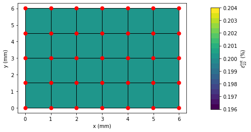

```
Total strain in horizontal direction:
slightly different cross-contraction due to different plastic properties in model sections
```

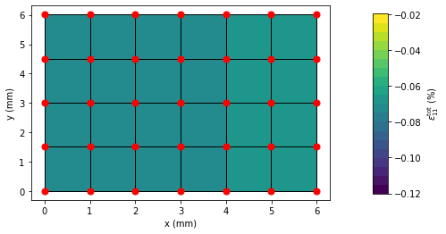

```
Equivalent total strain
```

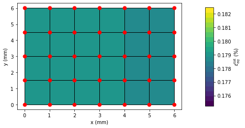

```python
'laminate model is generated and elastic-plastic properties are assigned to each section'
fem = FE.Model(dim=2, planestress=True)   # call class to generate object for finite element model
fem.geom([2, 2, 2], LY=6.)    # define sections in absolute lengths
fem.assign([mat1, mat2, mat3])  # assign the proper material to each section
fmat1 = 1./3.   # identical volume fraction for each material
fmat2 = 1./3.
fmat3 = 1./3.
'boundary conditions: uniaxial stress in longitudinal direction'
etot = 0.002
fem.bcleft(0.)                     # fix left and bottom boundary
fem.bcbot(0.)
fem.bcright(0., 'force')           # free boundary condition on right edge of model
fem.bctop(etot*fem.leny, 'disp')  # strain applied to top nodes
'solution and evalutation of effective properties'
fem.mesh(NX=6, NY=4) # create mesh
fem.solve()           # solve system of equations
fem.calc_global()     # calculate global stress and strain
print('2-d Model: uniaxial stress, isostrain condition')
print('-----------------------------------------------')
print('Global total strain: (eps_xx, eps_yy) = (%6.3f, %6.3f)' % (fem.glob['eps'][0], fem.glob['eps'][1]))
print('Local total strain (elements in different sections, Voigt tensor):')
print(fem.element[0].eps.round(decimals=3),' in Section 1, Material:',fem.element[0].Mat.name)
print(fem.element[8].eps.round(decimals=3),' in Section 2, Material:',fem.element[8].Mat.name)
print(fem.element[16].eps.round(decimals=3),' in Section 3, Material:',fem.element[16].Mat.name)
'create graphical output of total strains in FE model'
print('Total strain in vertical direction: isostrain condition fulfilled')
fem.plot('strain2')
print('Total strain in horizontal direction:')
print('slightly different cross-contraction due to different plastic properties in model sections')
fem.plot('strain1')
print('Equivalent total strain')
fem.plot('etot')
```

Since isostrain conditions are applied, the global total strain in vertical direction is identical in all elements, irrespective of their section and the assigned material. However, due to the differences in work hardening, slight changes in the horizontal strain show up. Next, we take a look at the plastic strains:

```
Global plastic strain: (epl_xx, epl_yy) = (-0.000245,  0.000491)
Local plastic strain (elements in different sections, Voigt tensor):
[-0.00025  0.0005  -0.00025  0.       0.       0.     ]  in Section 1, Material: isotropic, ideal plastic
[-0.000247  0.000494 -0.000247  0.        0.        0.      ]  in Section 2, Material: low work-hardening
[-0.000239  0.000479 -0.000239  0.        0.        0.      ]  in Section 3, Material: strong work-hardening
Plastic strain in vertical direction: differences due to work hardening
```

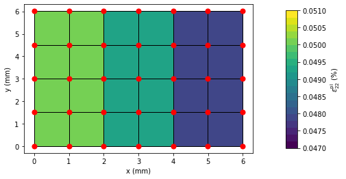

```
Plastic strain in horizontal direction: different plastic cross-contraction
```

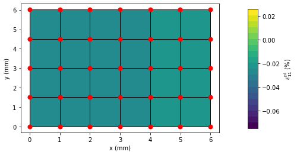

```
Equivalent plastic strain
```

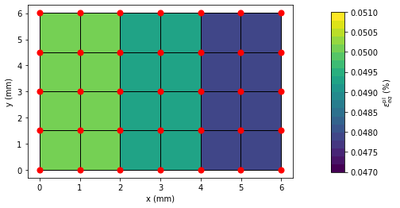

```python
print('Global plastic strain: (epl_xx, epl_yy) = (%9.6f, %9.6f)'
      % (fem.glob['epl'][0], fem.glob['epl'][1]))
print('Local plastic strain (elements in different sections, Voigt tensor):')
print(fem.element[0].epl.round(decimals=6),' in Section 1, Material:',fem.element[0].Mat.name)
print(fem.element[8].epl.round(decimals=6),' in Section 2, Material:',fem.element[8].Mat.name)
print(fem.element[16].epl.round(decimals=6),' in Section 3, Material:',fem.element[16].Mat.name)
'create graphical output of plastic strains in FE model'
print('Plastic strain in vertical direction: differences due to work hardening')
fem.plot('plastic2',vmin=0.047,vmax=0.051)
print('Plastic strain in horizontal direction: different plastic cross-contraction')
fem.plot('plastic1')
print('Equivalent plastic strain')
fem.plot('peeq',vmin=0.047,vmax=0.051)
```

```
Global stress: (sig_xx, sig_yy) = (-0.000, 301.841) MPa
Local stress (elements in different sections, Voigt tensor) (MPa):
[ -0. 300.   0.   0.   0.   0.]  in Section 1, Material: isotropic, ideal plastic
[ -0.    301.299   0.      0.      0.     -0.   ]  in Section 2, Material: low work-hardening
[ -0.    304.225   0.      0.      0.     -0.   ]  in Section 3, Material: strong work-hardening
Stress in vertical direction: different flow stresses at constant strain
```

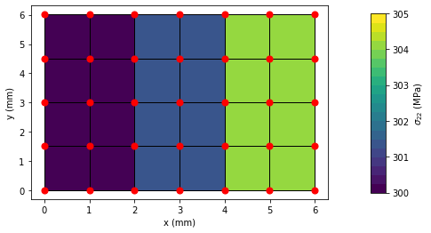

```
Stress in horizontal direction: uniaxial stress condition fulfilled
```

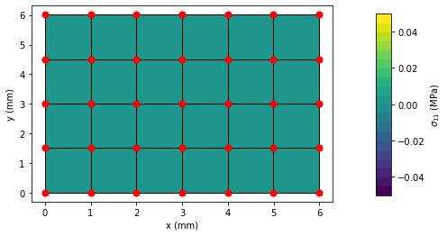

```
Equivalent stress: different flow stresses at constant strain
```

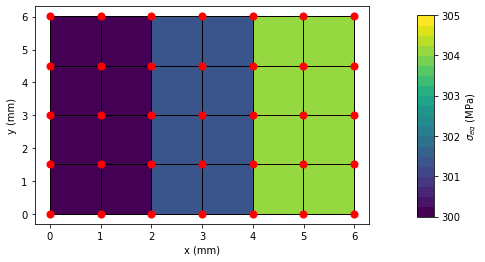

```python
print('Global stress: (sig_xx, sig_yy) = (%6.3f, %6.3f) MPa'
      % (fem.glob['sig'][0], fem.glob['sig'][1]))
print('Local stress (elements in different sections, Voigt tensor) (MPa):')
print(fem.element[0].sig.round(decimals=3),' in Section 1, Material:',fem.element[0].Mat.name)
print(fem.element[8].sig.round(decimals=3),' in Section 2, Material:',fem.element[8].Mat.name)
print(fem.element[16].sig.round(decimals=3),' in Section 3, Material:',fem.element[16].Mat.name)
'create graphical output of stress in FE model'
print('Stress in vertical direction: different flow stresses at constant strain')
fem.plot('stress2',vmin=300,vmax=305)
print('Stress in horizontal direction: uniaxial stress condition fulfilled')
fem.plot('stress1')
print('Equivalent stress: different flow stresses at constant strain')
fem.plot('seq',vmin=300,vmax=305)
```

## 4. Anisotropic materials

The pyLabFEA package also allows the definition of plastically anisotropic materials. When defining the plastic properties, the parameter `hill`$=[H_1, H_2, H_3]$ can be used to define orthotropic plastic properties in a Hill-like manner. The parameters are taken into account in a generalized equivalent stress

\begin{equation} \sigma_{eq} = \sqrt{ \frac{1}{2}\left[ H_1 \left(\sigma_1-\sigma_2\right)^2 + H_2 \left(\sigma_2-\sigma_3\right)^2 + H_3 \left(\sigma_3-\sigma_1\right)^2 \right] } . \end{equation}

In the first step, the yield locus of an anisotropic material is plotted together with the isotropic reference material `mat1`. Furthermore, the stresses obtained during the plastic deformation in the internal calculation of the stress-strain curves under the different loading conditions are also shown.

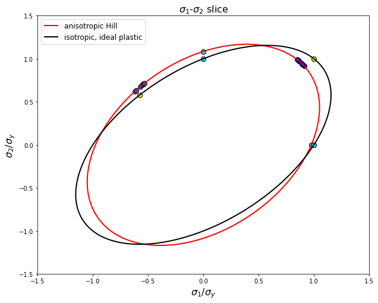

```python
'Material with anistropic plasticity as described by Hill-parameters'
tol = FE.ptol   # save tolerance original parameter
FE.ptol = 0.4   # increase tolerance value to speed up calculation for strongly anisotropic material
mat_an = Material(name='anisotropic Hill')
mat_an.elasticity(E=E, nu=nu)
mat_an.plasticity(sy=sy, hill=[0.7,1.,1.4])
mat_an.calc_properties(eps=0.005, sigeps=True)
FE.ptol = tol  # reset tolerance to its original value

'plot yield locus'
ax = mat_an.plot_yield_locus(xstart=-1.5, xend=1.5, ref_mat=mat1)
'plot evolution of stresses during loading for anisoptropy ...'
stx = mat_an.sigeps['stx']['sig'][:,0:2]/mat_an.sy
sty = mat_an.sigeps['sty']['sig'][:,0:2]/mat_an.sy
et2 = mat_an.sigeps['et2']['sig'][:,0:2]/mat_an.sy
ect = mat_an.sigeps['ect']['sig'][:,0:2]/mat_an.sy
ax.scatter(stx[1:,0],stx[1:,1],s=60, c='#00f0ff', edgecolors='k')
ax.scatter(sty[1:,0],sty[1:,1],s=60, c='#00f0ff', edgecolors='k')
ax.scatter(et2[1:,0],et2[1:,1],s=60, c='#0000ff', edgecolors='k')
ax.scatter(ect[1:,0],ect[1:,1],s=60, c='#0060ff', edgecolors='k')
'... and for the isotropic material mat1'
stx = mat1.sigeps['stx']['sig'][:,0:2]/mat1.sy
sty = mat1.sigeps['sty']['sig'][:,0:2]/mat1.sy
et2 = mat1.sigeps['et2']['sig'][:,0:2]/mat1.sy
ect = mat1.sigeps['ect']['sig'][:,0:2]/mat1.sy
ax.scatter(stx[1:,0],stx[1:,1],s=60, c='#00f0ff', edgecolors='k')
ax.scatter(sty[1:,0],sty[1:,1],s=60, c='#00f0ff', edgecolors='k')
ax.scatter(et2[1:,0],et2[1:,1],s=60, c='#ffff00', edgecolors='k')
ax.scatter(ect[1:,0],ect[1:,1],s=60, c='#ffff00', edgecolors='k')
```

It is seen how the shape of the yield locus gets deformed by the anisotropy paramaters. Furthermore, the graph shows that all obtained stress values during the calculation of the stress-strain curves lie on the yield locus. For both materials shown here, ideal plasticity is assumed such that the yield locus is not changed during plastic deformation. For the anisotropic material, the flow stresses obtained under equibiaxial strain and pure shear strain move on the yield locus, which is a consequence of the material anisotropy that changes the stress state during strain controled loading conditions. For loading cases leading to uniaxial stresses, the flow stress remains on on the same spot of the yield locus by definition.

Finally, the obtained stress strain courves are plotted for the two definitions of the equivalent stress: (i) isotropic J2 equivalent stress, (ii) Hill-like anisotropic equivalent stress.

```
---------------------------------------------------------
J2 yield stress under uniax-x loading: 292.77 MPa
---------------------------------------------------------
J2 yield stress under uniax-y loading: 325.396 MPa
---------------------------------------------------------
J2 yield stress under equibiax loading: 273.861 MPa
---------------------------------------------------------
J2 yield stress under shear loading: 322.252 MPa
---------------------------------------------------------
```

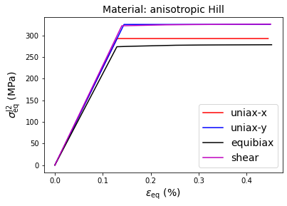

```
Hill yield stress under uniax-x loading: 300.0 MPa
---------------------------------------------------------
Hill yield stress under uniax-y loading: 300.0 MPa
---------------------------------------------------------
Hill yield stress under equibiax loading: 300.0 MPa
---------------------------------------------------------
Hill yield stress under shear loading: 300.0 MPa
---------------------------------------------------------
```

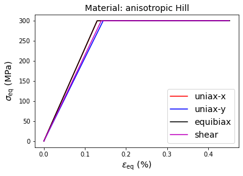

```python
mat_an.plot_stress_strain(Hill=True)
```

It can be seen that for anisotropy the two different ways to define the equivalent stress, result in different values describing the same material under the same loading conditions. While the J2 equivalent stress reveales the anisotropy of the material in different yield stresses, depending on the loading direction, the equivalent stress after Hill maps the yield stresses on a constant strength value. Note, that the nominal yield strength of the material is the constant in both cases.

## 5. Summary

This tutorial demonstrates the non-linear FEA with the pyLabFEA package. Yield loci and stress-strain curves for materials with isotropic plasticity and Hill-like anisotropic behavior are analysed. FE models with materials exhibiting different work hardening rates are generated and applied.

## 6. Exercises

- Create materials with different initial strengths and different work hardening rates and compare the results of the FE model.
- Create materials with identical plastic properties but different elasticity constants and compare the results of the FEA for loading in different directions.
- Combine different materials with identical yield strengths and work hardening rates, but differnt Hill parameters in one FE model and discuss the results.

## Tutorial 4: Homogenization

Laminate structures with different elastic-plastic materials are analyzed with respect to the mechanical behavior.

# Homogenization of non-linear materials

The mechanical properties of structures composed of materials with different elasto-plastic properties can be estimated based on the models of Taylor or Sachs. In this tutorial, structures composed of different materials are created and their mechanical properties are investigated and compared to the Taylor and Sachs solution. Non-linear Finite Element Analysis is performed with the pyLabFEA package, see the [online documentation](https://ahartmaier.github.io/pyLabFEA/) and the tutorial [Introduction](https://ahartmaier.github.io/pyLabFEA/examples.html#tutorial-1-introduction) for detailed information on the functionality of the package. For linear-elastic materials, analytical solutions for the homogenzition of their properties exist, as described in the tutorial [Composites](https://ahartmaier.github.io/pyLabFEA/examples.html#tutorial-2-composites). This tutorial uses the matplotlib (https://matplotlib.org/) library for the visualization of results, and NumPy (http://www.numpy.org) for mathematical operations with arrays.

Author: Alexander Hartmaier, ICAMS / Ruhr-Universität Bochum, Germany

March 2020

This work is licensed under a Creative Commons Attribution-NonCommercial-ShareAlike 4.0 International License [(CC-BY-NC-SA)](http://creativecommons.org/licenses/by-nc-sa/4.0/)

The pyLabFEA package comes with ABSOLUTELY NO WARRANTY. This is free software, and you are welcome to redistribute it under the conditions of the GNU General Public License [(GPLv3)](http://www.fsf.org/licensing/licenses/gpl.html)

```python
import sys
if ("../source" not in sys.path):
    sys.path.append("../source")

import pyLabFEM as FE
from pyLabMaterial import Material
import matplotlib.pyplot as plt
import numpy as np
```

## 1. Create elastic-plastic materials

In the first step, the class `Material` in invoked to create objects for three materials, with identical elastic properties, but different yield strengths. The unit of stress is 1 MPa. All features of the class `Material` are described in the [documentation](https://ahartmaier.github.io/pyLabFEA/pyLabFEA.html#module-pyLabMaterial).

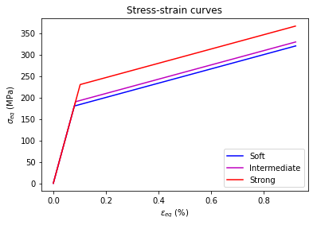

```python
mat1 = Material(name="Soft")          # invoke class to generate object for material 1
mat1.elasticity(E=200.e3, nu=0.3)     # define material with isotropic elasticity
mat1.plasticity(sy=180., khard=50.e3) # define material with isotropic plasticity and linear work hardening
mat2 = Material(name="Intermediate")  # define second material
mat2.elasticity(E=200.e3, nu=0.3)     # identic elastic properties as mat1
mat2.plasticity(sy=190., khard=50.e3) # higher yield strength than mat1, but same w.h. coefficient
mat3 = Material(name="Strong")        # define third material
mat3.elasticity(E=200.e3, nu=0.3)     # identic elastic properties as mat1
mat3.plasticity(sy=230., khard=50.e3) # higher yield strength than mat1 and mat2, but same w.h. coefficient
'Calculate and plot stress strain curves of materials'
mat1.calc_properties(eps=0.01)  # invoke method to calculate properties of material
mat2.calc_properties(eps=0.01)  # and to store stress-strain data up to total strain eps=1%
mat3.calc_properties(eps=0.01)
plt.plot(mat1.prop['sty']['eeq']*100., mat1.prop['stx']['seq'], '-b')  # plot equiv. strain (eeq) vs. equiv. stress (seq)
plt.plot(mat2.prop['sty']['eeq']*100., mat2.prop['stx']['seq'], '-m')  # for uniaxial tensile stress in vertical direction (sty)
plt.plot(mat3.prop['sty']['eeq']*100., mat3.prop['stx']['seq'], '-r')
plt.title('Stress-strain curves')
plt.xlabel(r'$\epsilon_{eq}$ (%)')
plt.ylabel(r'$\sigma_{eq}$ (MPa)')
plt.legend([mat1.name, mat2.name, mat3.name], loc='lower right')
plt.show()
```

## 2. Laminate structure under iso-strain condition (Taylor model)

The class `Model` is invoked to generate an object for FEA. The methods of the class are used to generate the geomtry, to assign materials to sections, to establish boundary conditions, and to create the mesh. After these pre-processing steps, the solver is called to determine the solution for the deformed shape of the laminate structure in mechanical equilibrium under the applied boundary conditions. In the post-processing step, the results are evaluated and visualized. See the tutorial [Introduction](https://ahartmaier.github.io/pyLabFEA/examples.html#tutorial-1-introduction) for the basic steps; all features of the class `Model` are described in the [documentation](https://ahartmaier.github.io/pyLabFEA/pyLabFEA.html).

The FE model of the laminate structure is subjected to a uniaxial stress along the lamellae of the structure, leading to iso-strain conditions, in which each section of the model, i.e. each lamella, undergoes the same total strain as the entire structure. The unit of length is 1 mm. In the first step, the model is loaded up to a stress slightly higher than the yield strength of `mat1`, and the strains are analyzed.

```
2-d Model: iso-strain, uniaxial stress
--------------------------------------
Global total strain: (eps_11, eps_22) = (-0.000300,  0.000900)
Local total strain (element solution in different sections, Voigt tensor)
[-0.0003  0.0009 -0.0003  0.      0.     -0.    ] in Section 1, Material:  Soft
[-0.00028  0.00094 -0.00028  0.       0.      -0.     ] in Section 2, Material:  Intermediate
[-0.00028  0.00094 -0.00028  0.       0.       0.     ] in Section 3, Material:  Strong

Global plastic strain: (epl_11, epl_22) = (-0.000000,  0.000000)
Local plastic strain (element solution in different sections, Voigt tensor):
[-6.0e-06  1.3e-05 -6.0e-06  0.0e+00  0.0e+00  0.0e+00]  in Section 1, Material: Soft
[0. 0. 0. 0. 0. 0.]  in Section 2, Material: Intermediate
[0. 0. 0. 0. 0. 0.]  in Section 3, Material: Strong
```

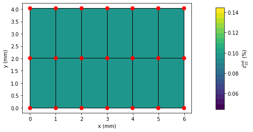

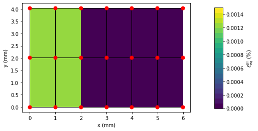

```python
'laminate model is generated and elastic-plastic properties are assigned to each section'
fem = FE.Model(dim=2, planestress=True) # generate an object for a 2d finite element model with plane stress conditions
fem.geom([2, 2, 2], LY=4.)      # define 3 horizontal sections with 2 micron width per section, vertical dimension is 4 micron
fem.assign([mat1, mat2, mat3])  # assign the proper material to each section
fmat1 = 1./3.                   # identical volume fraction for each material
fmat2 = 1./3.
fmat3 = 1./3.
'boundary conditions: uniaxial stress along the  direction of the lamellae'
fem.bcleft(0.)                     # fix left and bottom boundary in normal directions
fem.bcbot(0.)                      # nodes on lhs boundary can move up and down, bottom nodes can move left and right
fem.bcright(0., 'force')           # free boundary condition on right edge of plane stress model -> uniaxial stress condition
ubc = 1.05*fem.leny*mat1.sy/mat1.E # displacement on top boundary corresponding to yield strength of mat1 (+5%)
fem.bctop(ubc, 'disp') # displacement applied to top nodes
'generate mesh'
fem.mesh(NX=6, NY=2)   # create structured mesh
'solution of equations for mechanical equilibrium'
fem.solve()            # solve system of equations
'post-processing'
fem.calc_global()      # calculate global stress and strain

print('2-d Model: iso-strain, uniaxial stress')
print('--------------------------------------')
print('Global total strain: (eps_11, eps_22) = (%9.6f, %9.6f)'
      % (fem.glob['eps'][0].round(decimals=4), fem.glob['eps'][1].round(decimals=4)))
print('Local total strain (element solution in different sections, Voigt tensor)')
print(fem.element[0].eps.round(decimals=4),'in Section 1, Material: ', fem.element[0].Mat.name)
print(fem.element[4].eps.round(decimals=5),'in Section 2, Material: ', fem.element[4].Mat.name)
print(fem.element[8].eps.round(decimals=5),'in Section 3, Material: ', fem.element[8].Mat.name)
print('\nGlobal plastic strain: (epl_11, epl_22) = (%9.6f, %9.6f)'
      % (fem.glob['epl'][0].round(decimals=3), fem.glob['epl'][1].round(decimals=3)))
print('Local plastic strain (element solution in different sections, Voigt tensor):')
print(fem.element[0].epl.round(decimals=6),' in Section 1, Material:',fem.element[0].Mat.name)
print(fem.element[4].epl.round(decimals=6),' in Section 2, Material:',fem.element[4].Mat.name)
print(fem.element[8].epl.round(decimals=6),' in Section 3, Material:',fem.element[8].Mat.name)
'create graphical output of model'
fem.plot('strain2')                   # plot eps_22
fem.plot('peeq',vmin=0.,vmax=0.0015)  # plot eqiv. plastic strain
```

It is seen that the isostrain assumption is fulfilled to a very good degree, although the first section of the model, to which the soft material `mat1` is assigned starts to yield plastically, while the other sections remain linear-elastic.

The analysis of the stresses reveals that the stress in section 1 remains at the level of the flow stress in `mat1` (=yield strength + work hardening), while the stress in the two other sections is below the yield strength of those materials.

```
Global stress (MPa): (sig_11, sig_22) = ( 0.00, 186.34)
Local stress (element solution in different sections) (MPa):
[  0.   181.13   0.     0.     0.    -0.  ]  in Section 1, Material: Soft
[  0.   188.95   0.     0.     0.    -0.  ]  in Section 2, Material: Intermediate
[  0.   188.95   0.     0.     0.     0.  ]  in Section 3, Material: Strong
```

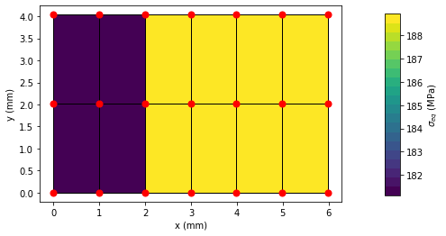

```python
print('\nGlobal stress (MPa): (sig_11, sig_22) = (%5.2f, %5.2f)'
      % (fem.glob['sig'][0].round(decimals=3), fem.glob['sig'][1].round(decimals=3)))
print('Local stress (element solution in different sections) (MPa):')
print(fem.element[0].sig.round(decimals=2),' in Section 1, Material:',fem.element[0].Mat.name)
print(fem.element[4].sig.round(decimals=2),' in Section 2, Material:',fem.element[4].Mat.name)
print(fem.element[8].sig.round(decimals=2),' in Section 3, Material:',fem.element[8].Mat.name)

fem.plot('seq')
```

In the next step the load is increased to exceed the yield strength of `mat2`, and the strains are analysed again. Note that only the boundary conditions need to be changed on the existing model.

```
2-d Model: isostrain, uniaxial stress
-------------------------------------
Global total strain: (epl_11, epl_22) = (-0.000300,  0.001000)
Local total strain (element solution in different sections, Voigt tensor)
[-0.0003  0.001  -0.0003  0.      0.     -0.    ] in Section 1, Material:  Soft
[-0.00031  0.001   -0.0003   0.       0.      -0.     ] in Section 2, Material:  Intermediate
[-0.0003  0.001  -0.0003  0.      0.      0.    ] in Section 3, Material:  Strong

Global plastic strain: (epl_11, epl_22) = (-0.000000,  0.000000)
Local plastic strain (element solution in different sections, Voigt tensor):
[-1.5e-05  3.0e-05 -1.5e-05  0.0e+00  0.0e+00  0.0e+00]  in Section 1, Material: Soft
[-6.0e-06  1.2e-05 -6.0e-06  0.0e+00  0.0e+00  0.0e+00]  in Section 2, Material: Intermediate
[0. 0. 0. 0. 0. 0.]  in Section 3, Material: Strong
```

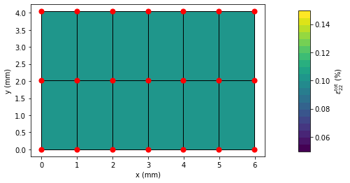

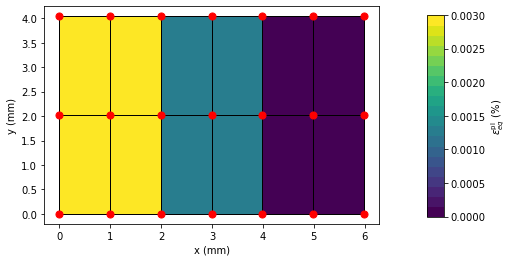

```python
'increase load up to yield strength of mat2'
ubc = 1.05*fem.leny*mat2.sy/mat1.E   # displacement on top boundary corresponding to yield strength of mat2 (+5%)
fem.bctop(ubc, 'disp')  # displacement applied to top nodes
fem.solve()             # solve system of equations
fem.calc_global()       # calculate global stress and strain
print('2-d Model: isostrain, uniaxial stress')
print('-------------------------------------')
print('Global total strain: (epl_11, epl_22) = (%9.6f, %9.6f)'
      % (fem.glob['eps'][0].round(decimals=4), fem.glob['eps'][1].round(decimals=4)))
print('Local total strain (element solution in different sections, Voigt tensor)')
print(fem.element[0].eps.round(decimals=4),'in Section 1, Material: ', fem.element[0].Mat.name)
print(fem.element[4].eps.round(decimals=5),'in Section 2, Material: ', fem.element[4].Mat.name)
print(fem.element[8].eps.round(decimals=5),'in Section 3, Material: ', fem.element[8].Mat.name)
print('\nGlobal plastic strain: (epl_11, epl_22) = (%9.6f, %9.6f)'
      % (fem.glob['epl'][0].round(decimals=3), fem.glob['epl'][1].round(decimals=3)))
print('Local plastic strain (element solution in different sections, Voigt tensor):')
print(fem.element[0].epl.round(decimals=6),' in Section 1, Material:',fem.element[0].Mat.name)
print(fem.element[4].epl.round(decimals=6),' in Section 2, Material:',fem.element[4].Mat.name)
print(fem.element[8].epl.round(decimals=6),' in Section 3, Material:',fem.element[8].Mat.name)
'create graphical output of model'
fem.plot('strain2')
fem.plot('peeq',vmin=0.,vmax=0.003)
```

Again, the iso-strain assumption is fulfilled very well, because all sections individually are subject to the same vertical strain as the entire structure. The plastic strain in section 1 increases, and also in section 2 plastic yielding sets in.

```
Global stress (MPa): (sig_11, sig_22) = ( 0.00, 190.66)
Local stress (element solution in different sections, Voigt tensor) (MPa):
[  0.   181.94   0.     0.     0.    -0.  ]  in Section 1, Material: Soft
[  0.   190.59   0.     0.     0.    -0.  ]  in Section 2, Material: Intermediate
[  0.   199.46   0.     0.     0.     0.  ]  in Section 3, Material: Strong
```

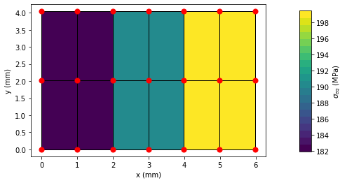

```python
print('\nGlobal stress (MPa): (sig_11, sig_22) = (%5.2f, %5.2f)'
      % (fem.glob['sig'][0].round(decimals=3), fem.glob['sig'][1].round(decimals=3)))
print('Local stress (element solution in different sections, Voigt tensor) (MPa):')
print(fem.element[0].sig.round(decimals=2),' in Section 1, Material:',fem.element[0].Mat.name)
print(fem.element[4].sig.round(decimals=2),' in Section 2, Material:',fem.element[4].Mat.name)
print(fem.element[8].sig.round(decimals=2),' in Section 3, Material:',fem.element[8].Mat.name)

fem.plot('seq')
```

The stress in sections 1 and 2 is bounded by the flow stress of the assigned materials, the stress in section 3 is still below the yield strength of `mat3`.

Finally, the strain applied on the model is increased to $\epsilon_{22} = 1$%.

```
2-d Model: isostrain, uniaxial stress
-------------------------------------
Global total strain: (epl_11, epl_22) = (-0.004700,  0.010000)
Local total strain (element solution in different sections, Voigt tensor)
[-0.0047  0.01   -0.0023  0.      0.      0.    ] in Section 1, Material:  Soft
[-0.00467  0.01    -0.00228  0.       0.      -0.     ] in Section 2, Material:  Intermediate
[-0.00463  0.01    -0.0023   0.       0.       0.     ] in Section 3, Material:  Strong

Global plastic strain: (epl_11, epl_22) = (-0.004000,  0.007000)
Local plastic strain (element solution in different sections, Voigt tensor):
[-0.003774  0.007548 -0.003774  0.        0.        0.      ]  in Section 1, Material: Soft
[-0.003765  0.007529 -0.003765  0.        0.        0.      ]  in Section 2, Material: Intermediate
[-0.003695  0.00739  -0.003695  0.        0.        0.      ]  in Section 3, Material: Strong
```

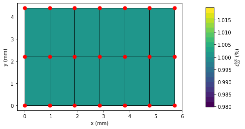

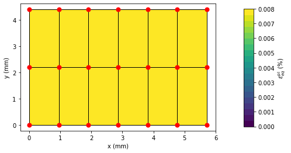

```python
'increase load up to eps_22=1%'
ubc = 0.01*fem.leny     # displacement on top boundary corresponding to 1% total strain
fem.bctop(ubc, 'disp')  # displacement applied to top nodes
fem.solve()             # solve system of equations
fem.calc_global()       # calculate global stress and strain

print('2-d Model: isostrain, uniaxial stress')
print('-------------------------------------')
print('Global total strain: (epl_11, epl_22) = (%9.6f, %9.6f)'
      % (fem.glob['eps'][0].round(decimals=4), fem.glob['eps'][1].round(decimals=4)))
print('Local total strain (element solution in different sections, Voigt tensor)')
print(fem.element[0].eps.round(decimals=4),'in Section 1, Material: ', fem.element[0].Mat.name)
print(fem.element[4].eps.round(decimals=5),'in Section 2, Material: ', fem.element[4].Mat.name)
print(fem.element[8].eps.round(decimals=5),'in Section 3, Material: ', fem.element[8].Mat.name)
print('\nGlobal plastic strain: (epl_11, epl_22) = (%9.6f, %9.6f)'
      % (fem.glob['epl'][0].round(decimals=3), fem.glob['epl'][1].round(decimals=3)))
print('Local plastic strain (element solution in different sections, Voigt tensor):')
print(fem.element[0].epl.round(decimals=6),' in Section 1, Material:',fem.element[0].Mat.name)
print(fem.element[4].epl.round(decimals=6),' in Section 2, Material:',fem.element[4].Mat.name)
print(fem.element[8].epl.round(decimals=6),' in Section 3, Material:',fem.element[8].Mat.name)
'create graphical output of model'
fem.plot('strain2')
fem.plot('peeq',vmin=0.,vmax=0.008)
```

The deformation of the laminate structure is now becoming visible, and the plastic strains in the different sections are rather similar, because most of the deformation is now of plastic nature, whereas the elastic contributions is quite small.

```
Global stress (MPa): (sig_11, sig_22) = (-0.00, 338.55)
Local stress (element solution in different sections, Voigt tensor) (MPa):
[ -0.   320.44   0.     0.     0.     0.  ]  in Section 1, Material: Soft
[ -0.   329.09   0.     0.     0.    -0.  ]  in Section 2, Material: Intermediate
[ -0.   366.11   0.     0.     0.     0.  ]  in Section 3, Material: Strong
```

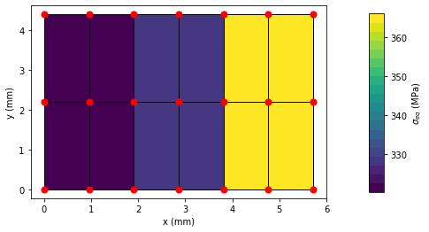

```python
print('\nGlobal stress (MPa): (sig_11, sig_22) = (%5.2f, %5.2f)'
      % (fem.glob['sig'][0].round(decimals=3), fem.glob['sig'][1].round(decimals=3)))
print('Local stress (element solution in different sections, Voigt tensor) (MPa):')
print(fem.element[0].sig.round(decimals=2),' in Section 1, Material:',fem.element[0].Mat.name)
print(fem.element[4].sig.round(decimals=2),' in Section 2, Material:',fem.element[4].Mat.name)
print(fem.element[8].sig.round(decimals=2),' in Section 3, Material:',fem.element[8].Mat.name)

fem.plot('seq')
```

The yield strength is now exceed in all sections, due to the linear work hardening with identical rate for each material, the difference in the yield strength is still reflected in the equivalent stress in each section, which corresponds to the flow stress of the assigned materials.

In the next step, the equiv. stress vs. equiv. strain diagram for the laminate structure is plotted together with those of the three materials.

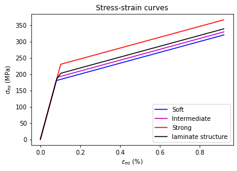

```python
'plot stress-strain curves of materials and laminate structure'
plt.plot(mat1.prop['sty']['eeq']*100., mat1.prop['stx']['seq'], '-b')
plt.plot(mat2.prop['sty']['eeq']*100., mat2.prop['stx']['seq'], '-m')
plt.plot(mat3.prop['sty']['eeq']*100., mat3.prop['stx']['seq'], '-r')
plt.plot(FE.eps_eq(fem.egl)*100., FE.seq_J2(fem.sgl), '-k')  # calculate and plot equivalent values of global strain and stress
plt.title('Stress-strain curves')
plt.xlabel(r'$\epsilon_{eq}$ (%)')
plt.ylabel(r'$\sigma_{eq}$ (MPa)')
plt.legend([mat1.name, mat2.name, mat3.name, 'laminate structure'], loc='lower right')
plt.show()
```

It is seen that the global stress for the laminate structure corresponds to the average of the stresses in the three sections, given by the flow stress of the assigned materials. According to the Taylor model, the stress average is calculated at a constant total strain $\epsilon_\mathrm{tot}$, which is equal to the total strain $\epsilon^{(i)}$ in each section $i$ (iso-strain assumption), thus

\begin{equation} \epsilon^{(i)} = \epsilon_\mathrm{tot} \hspace{2em} (i=1,2,3). \end{equation}

The global stress $\sigma_0$ is obtained by averaging the stresses $\sigma^{(i)}$ of the section according to their volume fractions $f_i$ , which yields

\begin{equation} \sigma_0 = \sum\limits_{i=1}^3 f_i \, \sigma^{(i)}(\epsilon_\mathrm{tot}). \end{equation}

In the next cell, the stresses according to the Taylor model are calculated and plotted together with the FE solution. To accomplish this, the FE model is restarted an the element solution in each section is recorded for small load increments until the total strain is reached.

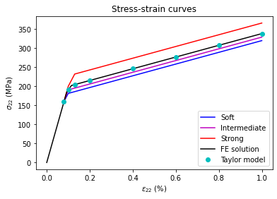

```python
'initialize arrays for element stresses and strains'
sig1=[]
sig2=[]
sig3=[]
etot=[]
'reset model to start with zero load; geometry, sections, boundary conditions and mesh are kept'
fem.u=None # reset model
'calculate FE solution for small load increments'
for eps in [8.e-4, 1.e-3, 1.3e-3, 2.e-3, 4.e-3, 6.e-3, 8.e-3, 1.e-2]:
    ubc = eps*fem.leny      # calculate load increment
    fem.bctop(ubc, 'disp')  # apply displacement on top nodes
    fem.solve()             # solve system of equations
    sig1.append(fem.element[0].sig[1])  # store element solution for each section
    sig2.append(fem.element[4].sig[1])
    sig3.append(fem.element[8].sig[1])
    etot.append(fem.element[0].eps[1]*100)

'calculate weigthed average of stresses in different sections at constant total strains'
s_taylor = fmat1*np.array(sig1) + fmat2*np.array(sig2) + fmat3*np.array(sig3)

'plot stresses and strains'
plt.plot(etot, sig1, '-b')
plt.plot(etot, sig2, '-m')
plt.plot(etot, sig3, '-r')
plt.plot(fem.egl[:,1]*100., fem.sgl[:,1], '-k')  # plot vertical components of global strain and stress
plt.plot(etot, s_taylor, 'oc')
plt.title('Stress-strain curves')
plt.xlabel(r'$\epsilon_{22}$ (%)')
plt.ylabel(r'$\sigma_{22}$ (MPa)')
plt.legend([mat1.name, mat2.name, mat3.name, 'FE solution', 'Taylor model'], loc='lower right')
plt.show()
```

It is seen that the results of the Taylor model and the FE solution are in excellent agreement. Furthermore, the element solution for the uniaxial stress state corresponds to the stress-strain curves obtained for the individual materials.

## 3. Laminate model under iso-stress conditions (Sachs model)

In the next step, a new model with the identical geometry and materials is generated, but subjected to a uniaxial strain in the direction transversal to lamellae. This load case results in an iso-stress condition that can be described with the Sachs model.

```
2-d Model: iso-stress, uniaxial strain
--------------------------------------
Global total strain: (epl_11, epl_22) = ( 0.001500,  0.000000)
Local total strain (element solution in different sections, Voigt tensor)
[ 0.0016 -0.      0.      0.      0.     -0.    ] in Section 1, Material:  Soft
[0.00152 0.      0.      0.      0.      0.     ] in Section 2, Material:  Intermediate
[0.00142 0.      0.      0.      0.      0.     ] in Section 3, Material:  Strong

Global plastic strain: (epl_11, epl_22) = ( 0.000000, -0.000000)
Local plastic strain (element solution in different sections, Voigt tensor):
[ 7.3e-05 -3.6e-05 -3.6e-05  0.0e+00  0.0e+00  0.0e+00]  in Section 1, Material: Soft
[ 5.0e-05 -2.5e-05 -2.5e-05  0.0e+00  0.0e+00  0.0e+00]  in Section 2, Material: Intermediate
[0. 0. 0. 0. 0. 0.]  in Section 3, Material: Strong
```

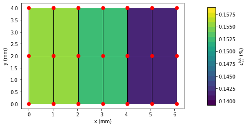

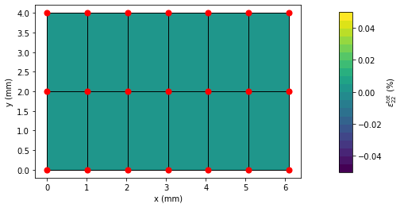

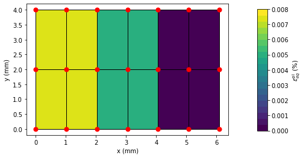

```python
'mechanical boundary conditions for Sachs model (iso-stress) with uniaxial strain'
fem = FE.Model(dim=2, planestress=False) # generate an object for a 2d finite element model with plane strain conditions
fem.geom([2, 2, 2], LY=4.)      # define 3 horizontal sections with 2 micron width per section, vertical dimension is 4 micron
fem.assign([mat1, mat2, mat3])  # assign the proper material to each section
fmat1 = 1./3.                   # identical volume fraction for each material
fmat2 = 1./3.
fmat3 = 1./3.
'boundary conditions: uniaxial stress in transversal direction'
fem.bcleft(0.)                  # fix left and bottom boundary in normal directions
fem.bcbot(0.)                   # nodes on lhs boundary can move up and down, bottom nodes can move left and right
ubc = 0.0015*fem.lenx           # apply uniaxial strain eps_11 = 0.15%
fem.bcright(ubc, 'disp')        # apply displacement on rhs nodes
fem.bctop(0., 'disp')           # top boundary is fixed for uniaxial strain
'generate mesh'
fem.mesh(NX=6, NY=2)            # create structured mesh
'solution of equations for mechanical equilibrium'
fem.solve()                     # solve system of equations
'post-processing'
fem.calc_global()               # calculate global stress and strain
print('2-d Model: iso-stress, uniaxial strain')
print('--------------------------------------')
print('Global total strain: (epl_11, epl_22) = (%9.6f, %9.6f)'
      % (fem.glob['eps'][0].round(decimals=4), fem.glob['eps'][1].round(decimals=4)))
print('Local total strain (element solution in different sections, Voigt tensor)')
print(fem.element[0].eps.round(decimals=4),'in Section 1, Material: ', fem.element[0].Mat.name)
print(fem.element[4].eps.round(decimals=5),'in Section 2, Material: ', fem.element[4].Mat.name)
print(fem.element[8].eps.round(decimals=5),'in Section 3, Material: ', fem.element[8].Mat.name)
print('\nGlobal plastic strain: (epl_11, epl_22) = (%9.6f, %9.6f)'
      % (fem.glob['epl'][0].round(decimals=3), fem.glob['epl'][1].round(decimals=3)))
print('Local plastic strain (element solution in different sections, Voigt tensor):')
print(fem.element[0].epl.round(decimals=6),' in Section 1, Material:',fem.element[0].Mat.name)
print(fem.element[4].epl.round(decimals=6),' in Section 2, Material:',fem.element[4].Mat.name)
print(fem.element[8].epl.round(decimals=6),' in Section 3, Material:',fem.element[8].Mat.name)
fem.plot('strain1')
fem.plot('strain2')
fem.plot('peeq',vmin=0., vmax=0.008)
```

It is seen that the uniaxial strain condition is applied and that sections 1 and 2 already underwent plastic deformation.

```
Global stress (MPa): (sig_11, sig_22) = (382.26, 183.83)
Local stress (element solution in different sections, Voigt tensor) (MPa):
[382.26 198.24 198.24   0.     0.    -0.  ]  in Section 1, Material: Soft
[382.26 189.42 189.42   0.     0.     0.  ]  in Section 2, Material: Intermediate
[382.26 163.83 163.83   0.     0.     0.  ]  in Section 3, Material: Strong
```

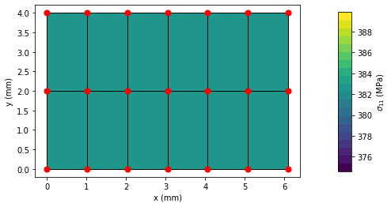

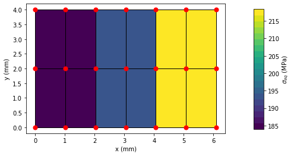

```python
print('\nGlobal stress (MPa): (sig_11, sig_22) = (%5.2f, %5.2f)'
      % (fem.glob['sig'][0].round(decimals=3), fem.glob['sig'][1].round(decimals=3)))
print('Local stress (element solution in different sections, Voigt tensor) (MPa):')
print(fem.element[0].sig.round(decimals=2),' in Section 1, Material:',fem.element[0].Mat.name)
print(fem.element[4].sig.round(decimals=2),' in Section 2, Material:',fem.element[4].Mat.name)
print(fem.element[8].sig.round(decimals=2),' in Section 3, Material:',fem.element[8].Mat.name)
fem.plot('stress1')
fem.plot('seq')
```

Also the iso-stress condition in loading direction is fullfilled. Transversal stresses occur due to the restricted cross-contraction, they are different in each section, due to their different plastic deformation, which is reflected in the different equivalent stresses in each section. Note also, that the stress state has a significant triaxiality, because the stress component in x-direction is larger than the equivalent stress, which is independent of hydrostatic stress components.

Now, the strain is increased to $\epsilon_\mathrm{tot} = 1%$, and the results are analyzed.

```
2-d Model: iso-stress, uniaxial strain
--------------------------------------
Global total strain: (epl_11, epl_22) = ( 0.010000,  0.000000)
Local total strain (element solution in different sections, Voigt tensor)
[ 0.0101 -0.      0.      0.      0.     -0.    ] in Section 1, Material:  Soft
[ 0.01004 -0.       0.       0.       0.      -0.     ] in Section 2, Material:  Intermediate
[0.00989 0.      0.      0.      0.      0.     ] in Section 3, Material:  Strong

Global plastic strain: (epl_11, epl_22) = ( 0.004000, -0.002000)
Local plastic strain (element solution in different sections, Voigt tensor):
[ 0.004311 -0.002156 -0.002156  0.        0.        0.      ]  in Section 1, Material: Soft
[ 0.004288 -0.002144 -0.002144  0.        0.        0.      ]  in Section 2, Material: Intermediate
[ 0.004168 -0.002084 -0.002084  0.        0.        0.      ]  in Section 3, Material: Strong
```

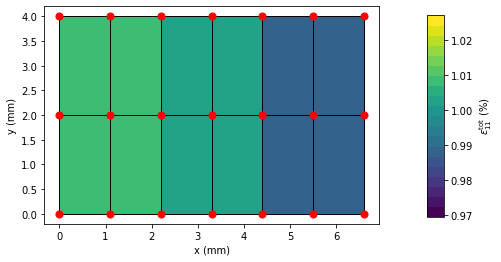

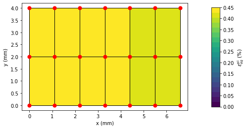

```python
'increase load'
ubc = 0.01*fem.lenx
fem.bcright(ubc, 'disp') # displacement on rhs nodes
fem.solve()              # solve equations for mechanical equilibrium
fem.calc_global()        # calculate global stress and strain
print('2-d Model: iso-stress, uniaxial strain')
print('--------------------------------------')
print('Global total strain: (epl_11, epl_22) = (%9.6f, %9.6f)'
      % (fem.glob['eps'][0].round(decimals=4), fem.glob['eps'][1].round(decimals=4)))
print('Local total strain (element solution in different sections, Voigt tensor)')
print(fem.element[0].eps.round(decimals=4),'in Section 1, Material: ', fem.element[0].Mat.name)
print(fem.element[4].eps.round(decimals=5),'in Section 2, Material: ', fem.element[4].Mat.name)
print(fem.element[8].eps.round(decimals=5),'in Section 3, Material: ', fem.element[8].Mat.name)
print('\nGlobal plastic strain: (epl_11, epl_22) = (%9.6f, %9.6f)'
      % (fem.glob['epl'][0].round(decimals=3), fem.glob['epl'][1].round(decimals=3)))
print('Local plastic strain (element solution in different sections, Voigt tensor):')
print(fem.element[0].epl.round(decimals=6),' in Section 1, Material:',fem.element[0].Mat.name)
print(fem.element[4].epl.round(decimals=6),' in Section 2, Material:',fem.element[4].Mat.name)
print(fem.element[8].epl.round(decimals=6),' in Section 3, Material:',fem.element[8].Mat.name)
fem.plot('strain1')
fem.plot('peeq',vmin=0., vmax=0.45)
```

Similar to the iso-strain conditions, the model is now fully plastified. Under uniaxial strain, however, the plastic deformation is smaller than for uniaxial stress, due to the pronounced stress triaxiality that is caused by the restricted cross-contraction.

Looking at the stresses reveals these strong components transversal to the loading direction.

```
Global stress (MPa): (sig_11, sig_22) = (1860.03, 1569.95)
Local stress (element solution in different sections, Voigt tensor) (MPa):
[1860.03 1587.79 1587.79    0.      0.      0.  ]  in Section 1, Material: Soft
[1860.03 1578.97 1578.97    0.      0.     -0.  ]  in Section 2, Material: Intermediate
[1860.03 1543.09 1543.09    0.      0.      0.  ]  in Section 3, Material: Strong
```

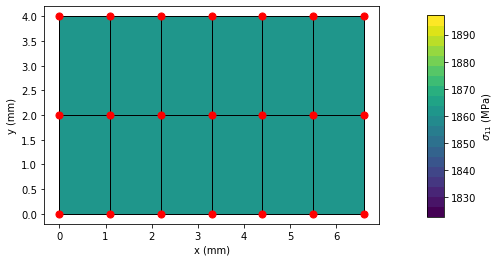

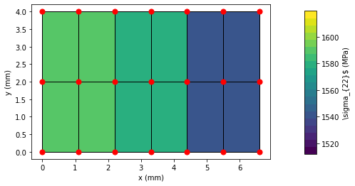

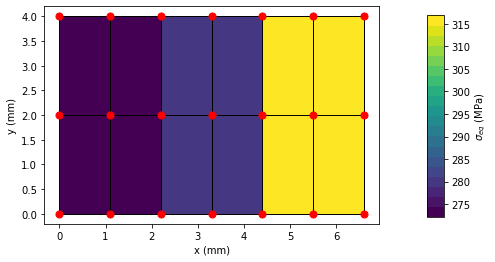

```python
print('\nGlobal stress (MPa): (sig_11, sig_22) = (%5.2f, %5.2f)'
      % (fem.glob['sig'][0].round(decimals=3), fem.glob['sig'][1].round(decimals=3)))
print('Local stress (element solution in different sections, Voigt tensor) (MPa):')
print(fem.element[0].sig.round(decimals=2),' in Section 1, Material:',fem.element[0].Mat.name)
print(fem.element[4].sig.round(decimals=2),' in Section 2, Material:',fem.element[4].Mat.name)
print(fem.element[8].sig.round(decimals=2),' in Section 3, Material:',fem.element[8].Mat.name)
fem.plot('stress1')
fem.plot('stress2')
fem.plot('seq')
```

The iso-stress condition in loading direction is fullfilled, i.e. the horizontal stress component is constant throughout the model. However, it is seen that due to the severe stress triaxiality, there are different equivalent stresses in the different sections, following the strengths of the assigned materials.

The homogenization under iso-stress conditions is covered by the Sachs model, where the stress in each section $\sigma^{(i)}$ equals the global stress $\sigma_0$, thus

\begin{equation} \sigma^{(i)} = \sigma_0 \hspace{2em} (i=1,2,3). \end{equation}

The global total strain is given as the weighted average of the total strain in each section $\epsilon_\mathrm{tot}^{(i)}$ at a constant stress $\sigma_0$ with the volume fractions $f_i$ as weights, which yields

\begin{equation} \epsilon_\mathrm{tot} = \sum\limits_{i=1}^3 f_i \, \epsilon_\mathrm{tot}^{(i)}(\sigma_0). \end{equation}

In the next cell, the strains according to the Sachs model are calculated from the element solutions in each section and plotted together with the global solution.

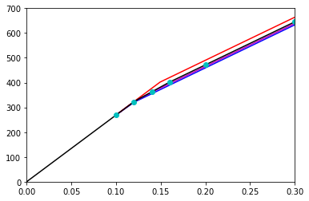

```python
sig0=[]
seq1=[]
seq2=[]
seq3=[]
et1=[]
et2=[]
et3=[]
eq1=[]
eq2=[]
eq3=[]
fem.u=None # reset model
for eps in [1.e-3, 1.2e-3, 1.4e-3, 1.6e-3, 2.e-3, 3.e-3, 6.5e-3, 1.e-2]:
    ubc = eps*fem.lenx          #  uniaxial strain increments
    fem.bcright(ubc, 'disp')    # apply displacement on rhs nodes
    fem.solve()                 # solve system of equations
    sig0.append(fem.element[0].sig[0])
    et1.append(fem.element[0].eps[0]*100)
    et2.append(fem.element[4].eps[0]*100)
    et3.append(fem.element[8].eps[0]*100)
    seq1.append(FE.seq_J2(fem.element[0].sig))
    seq2.append(FE.seq_J2(fem.element[4].sig))
    seq3.append(FE.seq_J2(fem.element[8].sig))
    eq1.append(FE.eps_eq(fem.element[0].eps)*100)
    eq2.append(FE.eps_eq(fem.element[4].eps)*100)
    eq3.append(FE.eps_eq(fem.element[8].eps)*100)

'weigthed average of strains in different sections at same stress level'
e_sachs = fmat1*np.array(et1) + fmat2*np.array(et2) + fmat3*np.array(et3)
'plot stresses and strains'
plt.plot(et1, sig0, '-b')
plt.plot(et2, sig0, '-m')
plt.plot(et3, sig0, '-r')
plt.plot(fem.egl[:,0]*100, fem.sgl[:,0], '-k')  # plot horizontal components of global strain and stress
plt.plot(e_sachs, sig0, 'oc')
plt.xlim((0,0.3))
plt.ylim((0,700))
plt.show()
```

The numerical solution and the Sachs model are in excellent agreement. Due to the large stress triaxility, the values of the flow stress are quite high, such that the differences between the different sections, caused by the comparatively small differences in the yield strength of each material, appear to be small in comparison. Thus, the evolution of equivalent stresses and equivalent strains in the elemnts of each section is also evaluated.

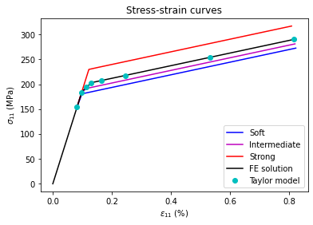

```python
'weigthed average of equiv. strains and stresses in different sections'
eeq_sachs = fmat1*np.array(eq1) +  fmat2*np.array(eq2) +  fmat3*np.array(eq3)
seq_sachs = fmat1*np.array(seq1) + fmat2*np.array(seq2) + fmat3*np.array(seq3)
'plot stresses and strains'
plt.plot(eq1, seq1, '-b')
plt.plot(eq2, seq2, '-m')
plt.plot(eq3, seq3, '-r')
plt.plot(FE.eps_eq(fem.egl)*100., FE.seq_J2(fem.sgl), '-k')  # plot horizontal components of global strain and stress
plt.plot(eeq_sachs, seq_sachs, 'oc')
plt.title('Stress-strain curves')
plt.xlabel(r'$\epsilon_{11}$ (%)')
plt.ylabel(r'$\sigma_{11}$ (MPa)')
plt.legend([mat1.name, mat2.name, mat3.name, 'FE solution', 'Taylor model'], loc='lower right')
plt.show()
```

The analysis of eqivalent stresses and strains makes the influence of the material properties more visible. In the next plot, Taylor and Sachs solutions are compared.

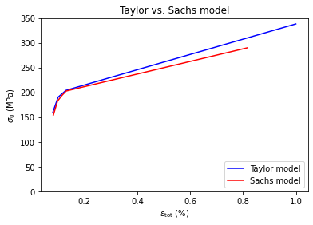

```python
plt.plot(etot, s_taylor, '-b')
plt.plot(eeq_sachs, seq_sachs, '-r')
plt.title('Taylor vs. Sachs model')
plt.xlabel(r'$\epsilon_\mathrm{tot}$ (%)')
plt.ylabel(r'$\sigma_0$ (MPa)')
plt.legend(['Taylor model', 'Sachs model'], loc='lower right')
plt.ylim((0,350))
plt.show()
```

The Taylor model (iso-strain) results in a stronger material behavior than the Sachs model (iso-stress), in which the softer regions dominate the behavior of the entire structure.

### Iso-stress approximation by uniaxial stress

In the next step, we investigate how applying a uni-axial stress transversal to the laminate structure changes the results.

```
2-d Model: transversal uniaxial stress
--------------------------------------
Global total strain: (eps_11, eps_22) = ( 0.000900, -0.000300)
Local total strain (element solution in different sections, Voigt tensor)
[ 0.001  -0.0003 -0.0003  0.      0.      0.    ] in Section 1, Material:  Soft
[ 1.0e-03 -3.1e-04 -3.0e-04  0.0e+00  0.0e+00  1.0e-05] in Section 2, Material:  Soft
[ 0.00092 -0.00029 -0.00027  0.       0.       0.     ] in Section 3, Material:  Intermediate

Global plastic strain: (epl_11, epl_22) = ( 0.000000, -0.000000)
Local plastic strain (element solution in different sections, Voigt tensor):
[ 3.6e-05 -1.8e-05 -1.8e-05  0.0e+00  0.0e+00  0.0e+00]  in Section 1, Material: Soft
[ 2.9e-05 -1.4e-05 -1.4e-05  0.0e+00  0.0e+00  0.0e+00]  in Section 2, Material: Soft
[0. 0. 0. 0. 0. 0.]  in Section 3, Material: Intermediate
```

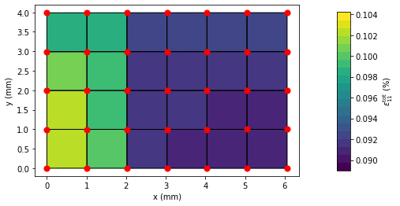

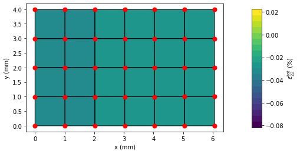

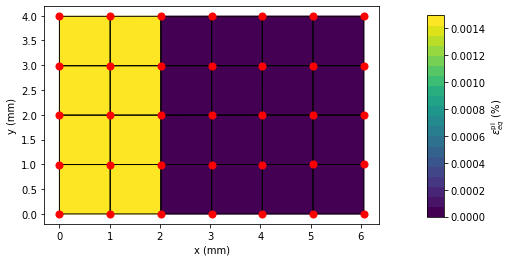

```python
'laminate model is generated and elastic-plastic properties are assigned to each section'
fem = FE.Model(dim=2, planestress=True) # generate an object for a 2d finite element model with plane stress conditions
fem.geom([2, 2, 2], LY=4.)      # define 3 horizontal sections with 2 micron width per section, vertical dimension is 4 micron
fem.assign([mat1, mat2, mat3])  # assign the proper material to each section
fmat1 = 1./3.                   # identical volume fraction for each material
fmat2 = 1./3.
fmat3 = 1./3.
'boundary conditions: uniaxial stress in transversal direction'
fem.bcleft(0.)                     # fix left and bottom boundary in normal directions
fem.bcbot(0.)                      # nodes on lhs boundary can move up and down, bottom nodes can move left and right
fem.bctop(0., 'force')             # free boundary condition on top edge of plane stress model -> uniaxial stress condition
ubc = 1.05*fem.lenx*mat1.sy/mat1.E # displacement on rhs boundary corresponding to yield strength of mat1 (+5%)
fem.bcright(ubc, 'disp')           # displacement applied to rhs nodes
'generate mesh'
fem.mesh(NX=6, NY=4)   # create structured mesh with higer number of elements in verical direction
'solution of equations for mechanical equilibrium'
fem.solve()            # solve system of equations
'post-processing'
fem.calc_global()      # calculate global stress and strain

print('2-d Model: transversal uniaxial stress')
print('--------------------------------------')
print('Global total strain: (eps_11, eps_22) = (%9.6f, %9.6f)'
      % (fem.glob['eps'][0].round(decimals=4), fem.glob['eps'][1].round(decimals=4)))
print('Local total strain (element solution in different sections, Voigt tensor)')
print(fem.element[0].eps.round(decimals=4),'in Section 1, Material: ', fem.element[0].Mat.name)
print(fem.element[4].eps.round(decimals=5),'in Section 2, Material: ', fem.element[4].Mat.name)
print(fem.element[8].eps.round(decimals=5),'in Section 3, Material: ', fem.element[8].Mat.name)
print('\nGlobal plastic strain: (epl_11, epl_22) = (%9.6f, %9.6f)'
      % (fem.glob['epl'][0].round(decimals=3), fem.glob['epl'][1].round(decimals=3)))
print('Local plastic strain (element solution in different sections, Voigt tensor):')
print(fem.element[0].epl.round(decimals=6),' in Section 1, Material:',fem.element[0].Mat.name)
print(fem.element[4].epl.round(decimals=6),' in Section 2, Material:',fem.element[4].Mat.name)
print(fem.element[8].epl.round(decimals=6),' in Section 3, Material:',fem.element[8].Mat.name)
'create graphical output of model'
fem.plot('strain1')                   # plot eps_11
fem.plot('strain2')                   # plot eps_22
fem.plot('peeq',vmin=0.,vmax=0.0015)  # plot eqiv. plastic strain
```

Plastic yielding starts again in section 1, in which also the total strain localises. This causes also a slight difference in the cross contraction of section 1 compared to the other sections.

```
Global stress (MPa): (sig_11, sig_22) = (182.97, -0.00)
Local stress (element solution in different sections, Voigt tensor) (MPa):
[1.838e+02 3.060e+00 0.000e+00 0.000e+00 0.000e+00 1.800e-01]  in Section 1, Material: Soft
[183.2    2.56   0.     0.     0.     0.39]  in Section 2, Material: Soft
[182.49  -3.75   0.     0.     0.     0.34]  in Section 3, Material: Intermediate
```

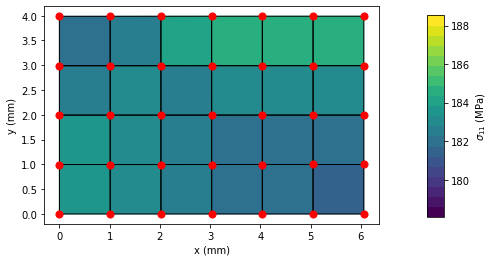

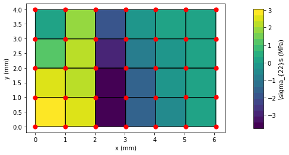

```python
print('\nGlobal stress (MPa): (sig_11, sig_22) = (%5.2f, %5.2f)'
      % (fem.glob['sig'][0].round(decimals=3), fem.glob['sig'][1].round(decimals=3)))
print('Local stress (element solution in different sections, Voigt tensor) (MPa):')
print(fem.element[0].sig.round(decimals=2),' in Section 1, Material:',fem.element[0].Mat.name)
print(fem.element[4].sig.round(decimals=2),' in Section 2, Material:',fem.element[4].Mat.name)
print(fem.element[8].sig.round(decimals=2),' in Section 3, Material:',fem.element[8].Mat.name)
fem.plot('stress1')
fem.plot('stress2')
```

The different cross-contractions of the sections cause significant stress components transversal to the loading direction. hence, altough the applied boundary condition correspond to a uniaxial stress, within the structure, the stress state deviates from the applied one.

```
2-d Model: iso-stress, uniaxial strain
--------------------------------------
Global total strain: (epl_11, epl_22) = ( 0.001200, -0.000400)
Local total strain (element solution in different sections, Voigt tensor)
[ 0.0017 -0.0006 -0.0005  0.      0.      0.    ] in Section 1, Material:  Soft
[ 1.56e-03 -5.40e-04 -4.40e-04  0.00e+00  0.00e+00  2.00e-05] in Section 2, Material:  Soft
[ 1.21e-03 -4.40e-04 -3.30e-04  0.00e+00  0.00e+00  2.00e-05] in Section 3, Material:  Intermediate

Global plastic strain: (epl_11, epl_22) = ( 0.000000, -0.000000)
Local plastic strain (element solution in different sections, Voigt tensor):
[ 0.000248 -0.000118 -0.000131  0.        0.        0.      ]  in Section 1, Material: Soft
[ 2.07e-04 -9.80e-05 -1.08e-04  0.00e+00  0.00e+00  0.00e+00]  in Section 2, Material: Soft
[ 8.7e-05 -4.6e-05 -4.1e-05  0.0e+00  0.0e+00  0.0e+00]  in Section 3, Material: Intermediate
```

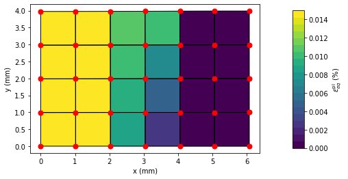

```
Global stress (MPa): (sig_11, sig_22) = (193.23,  0.00)
Local stress (element solution in different sections, Voigt tensor) (MPa):
[197.18   9.45   0.     0.     0.     0.56]  in Section 1, Material: Soft
[195.45  10.1    0.     0.     0.     1.55]  in Section 2, Material: Soft
[192.46  -4.23   0.     0.     0.     1.88]  in Section 3, Material: Intermediate
```

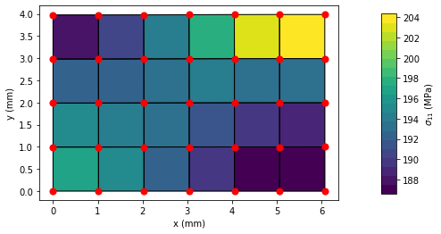

```python
'increase load above the yield strength of mat2'
ubc = 1.3*fem.lenx*mat2.sy/mat2.E
fem.bcright(ubc, 'disp') # displacement on rhs nodes
fem.solve()              # solve equations for mechanical equilibrium
fem.calc_global()        # calculate global stress and strain

print('2-d Model: iso-stress, uniaxial strain')
print('--------------------------------------')
print('Global total strain: (epl_11, epl_22) = (%9.6f, %9.6f)'
      % (fem.glob['eps'][0].round(decimals=4), fem.glob['eps'][1].round(decimals=4)))
print('Local total strain (element solution in different sections, Voigt tensor)')
print(fem.element[0].eps.round(decimals=4),'in Section 1, Material: ', fem.element[0].Mat.name)
print(fem.element[4].eps.round(decimals=5),'in Section 2, Material: ', fem.element[4].Mat.name)
print(fem.element[8].eps.round(decimals=5),'in Section 3, Material: ', fem.element[8].Mat.name)
print('\nGlobal plastic strain: (epl_11, epl_22) = (%9.6f, %9.6f)'
      % (fem.glob['epl'][0].round(decimals=3), fem.glob['epl'][1].round(decimals=3)))
print('Local plastic strain (element solution in different sections, Voigt tensor):')
print(fem.element[0].epl.round(decimals=6),' in Section 1, Material:',fem.element[0].Mat.name)
print(fem.element[4].epl.round(decimals=6),' in Section 2, Material:',fem.element[4].Mat.name)
print(fem.element[8].epl.round(decimals=6),' in Section 3, Material:',fem.element[8].Mat.name)
fem.plot('peeq',vmin=0., vmax=0.015)
print('\nGlobal stress (MPa): (sig_11, sig_22) = (%5.2f, %5.2f)'
      % (fem.glob['sig'][0].round(decimals=3), fem.glob['sig'][1].round(decimals=3)))
print('Local stress (element solution in different sections, Voigt tensor) (MPa):')
print(fem.element[0].sig.round(decimals=2),' in Section 1, Material:',fem.element[0].Mat.name)
print(fem.element[4].sig.round(decimals=2),' in Section 2, Material:',fem.element[4].Mat.name)
print(fem.element[8].sig.round(decimals=2),' in Section 3, Material:',fem.element[8].Mat.name)
fem.plot('stress1')
```

Upon further loading, the work hardening in section 1 causes the flow stress in this region to increase. Finally, the stress in the laminate structure exceeds the yield strength of the material in section 2. The iso-stress condition is fulfilled to some approximation in the structure, although the different sections reveal pronounced differences in the cross-contraction.

```
2-d Model: iso-stress, uniaxial strain
--------------------------------------
Global total strain: (epl_11, epl_22) = ( 0.010000, -0.004900)
Local total strain (element solution in different sections, Voigt tensor)
[ 0.0114 -0.0054 -0.0026  0.      0.     -0.    ] in Section 1, Material:  Soft
[ 0.01127 -0.00527 -0.00257  0.       0.       0.     ] in Section 2, Material:  Soft
[ 1.033e-02 -5.090e-03 -2.250e-03  0.000e+00  0.000e+00  2.000e-05] in Section 3, Material:  Intermediate

Global plastic strain: (epl_11, epl_22) = ( 0.006000, -0.003000)
Local plastic strain (element solution in different sections, Voigt tensor):
[ 0.00631  -0.003057 -0.003253  0.        0.        0.      ]  in Section 1, Material: Soft
[ 0.00635  -0.002948 -0.003402  0.        0.        0.      ]  in Section 2, Material: Soft
[ 0.006034 -0.002795 -0.003239  0.        0.        0.      ]  in Section 3, Material: Intermediate
```

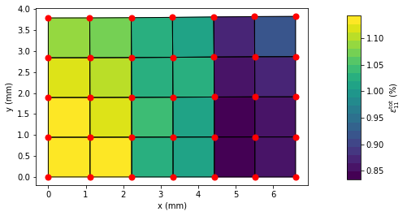

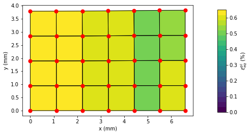

```python
'increase load to eps_11=1%'
ubc = 0.01*fem.lenx
fem.bcright(ubc, 'disp') # displacement on rhs nodes
fem.solve()              # solve equations for mechanical equilibrium
fem.calc_global()        # calculate global stress and strain

print('2-d Model: iso-stress, uniaxial strain')
print('--------------------------------------')
print('Global total strain: (epl_11, epl_22) = (%9.6f, %9.6f)'
      % (fem.glob['eps'][0].round(decimals=4), fem.glob['eps'][1].round(decimals=4)))
print('Local total strain (element solution in different sections, Voigt tensor)')
print(fem.element[0].eps.round(decimals=4),'in Section 1, Material: ', fem.element[0].Mat.name)
print(fem.element[4].eps.round(decimals=5),'in Section 2, Material: ', fem.element[4].Mat.name)
print(fem.element[8].eps.round(decimals=5),'in Section 3, Material: ', fem.element[8].Mat.name)
print('\nGlobal plastic strain: (epl_11, epl_22) = (%9.6f, %9.6f)'
      % (fem.glob['epl'][0].round(decimals=3), fem.glob['epl'][1].round(decimals=3)))
print('Local plastic strain (element solution in different sections, Voigt tensor):')
print(fem.element[0].epl.round(decimals=6),' in Section 1, Material:',fem.element[0].Mat.name)
print(fem.element[4].epl.round(decimals=6),' in Section 2, Material:',fem.element[4].Mat.name)
print(fem.element[8].epl.round(decimals=6),' in Section 3, Material:',fem.element[8].Mat.name)
fem.plot('strain1')
fem.plot('peeq',vmin=0., vmax=0.65)
```

At the maximum strain, the laminate structure is again fully plastified. The total strain in loading direction reflects the different states of work hardening in the materials assigned to the different sections.

```
Global stress (MPa): (sig_11, sig_22) = (339.06,  0.00)
Local stress (element solution in different sections, Voigt tensor) (MPa):
[ 3.426e+02  4.500e-01  0.000e+00  0.000e+00  0.000e+00 -1.500e-01]  in Section 1, Material: Soft
[3.4306e+02 6.2700e+00 0.0000e+00 0.0000e+00 0.0000e+00 1.3000e-01]  in Section 2, Material: Soft
[342.67  14.36   0.     0.     0.     1.55]  in Section 3, Material: Intermediate
```

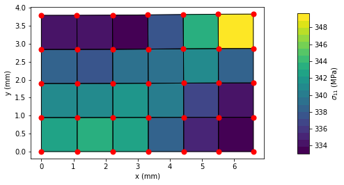

```python
print('\nGlobal stress (MPa): (sig_11, sig_22) = (%5.2f, %5.2f)'
      % (fem.glob['sig'][0].round(decimals=3), fem.glob['sig'][1].round(decimals=3)))
print('Local stress (element solution in different sections, Voigt tensor) (MPa):')
print(fem.element[0].sig.round(decimals=2),' in Section 1, Material:',fem.element[0].Mat.name)
print(fem.element[4].sig.round(decimals=2),' in Section 2, Material:',fem.element[4].Mat.name)
print(fem.element[8].sig.round(decimals=2),' in Section 3, Material:',fem.element[8].Mat.name)
fem.plot('stress1')
```

The iso-stress assumption is still fulfilled within an error margin of 5%, despite the different cross contractions

## 4. Summary

This tutorial demonstrates the homogenization of structures composed of materials with different elastic-plastic properties by non-linear FEA. Models fhe different load cases leading to iso-strain and iso-stress conditions in the structures are set up and the results are analyzed. It is seen that the numerical solution agrees very well with the analyitcal homogenization rules according to the Taylor and Sachs models.

## 5. Exercises

- Create materials with different hardening rates, e.g. 100 GPa for `mat1`, 50 GPa for `mat2` and 10 GPa for `mat3` and observe how the homogenized stress behaves in that case.
- Create a model in which the sections are not equally distributed and verify the correctness of the Taylor and Sachs models in this case.
- Assign a purely elastic material to one of the sections and study the behavior of the structure.

## Application 1: Machine Learning Flow Rule

In this application, a machine learning algorithm is trained to be used as constitutive model for anisotropic plasticity of metals.

# Machine Learning flow rule

Machine Learning (ML) algorithms provide a great flexibility to describe aribitrary mathematical functions. At the same time they offer the possibility to handle large data sets and multi-dimensional features as input. Hence, using ML algorithms as constitutive rules for plastic material behavior offers the possibility to explicitly take into account microstructural information of the material in the constitutive modeling. Furthermore, data resulting from experiment and micromechanical simulations can be hybridized to generate training data sets. The present example is using Support Vector Classification (SVC) as yield function. The SVC algorithm is trained by using deviatoric stresses as input data and the information whether a given stress state leads to purely elastic or rather to elastic-plastic deformation of the material as result data. In this way, a ML yield function is obtained, which can determine whether a given stress state lies inside or outside of the elastic regime of the material. Furthermore, the yield locus, i.e., the hyperplane in stress space on which plastic deformation occurs, can be reconstructed from the SVC, and the gradient on this yield locus can be conveniently calculated. Therefore, the standard formulations of continuum plasticity, as the return mapping algorithm, can be applied in Finite Element Analysis (FEA) in the usual way. Thus, it is demonstrated that the new ML yield function can replace conventional FEA yield functions. In a next step, microstructural information will be considered directly as feature. Machine learning algorithms have been adopted from the scikit-learn platform (https://scikit-learn.org/stable/).

This package demonstrates the training and application of ML flow rules in FEA in form of a simple example with data synthetically produced from standard flow rules, like isotropic J2 (von Mises) and Hill-type anisotropic plasticity. It uses the pyLabFEM module. This notebook uses the matplotlib (https://matplotlib.org/) library for the visualization of results, and NumPy (http://www.numpy.org) for mathematical operations with arrays.

Author: Alexander Hartmaier, ICAMS, Ruhr-Universtität Bochum, Germany, March 2020

This work is licensed under a Creative Commons Attribution-NonCommercial-ShareAlike 4.0 International License [(CC-BY-NC-SA)](http://creativecommons.org/licenses/by-nc-sa/4.0/)

The pyLabFEA package comes with ABSOLUTELY NO WARRANTY. This is free software, and you are welcome to redistribute it under the conditions of the GNU General Public License [(GPLv3)](http://www.fsf.org/licensing/licenses/gpl.html)

## Theoretical background

The yield function of a material is defined as \begin{equation} f = \sigma_{eq} - \sigma_y\,, \end{equation} where plastic deformation sets in at $f=0$, i.e. when the the equivalent stress $\sigma_{eq}$ equals the yield strength $\sigma_y$ of the material. The equivalent stress used here is based on the pricipal stresses $\sigma_i$ with $(i=1, 2, 3)$, as

\begin{equation} \sigma^\mathrm{J2}_{eq} = \sqrt{ \frac{1}{2}\left[ H_1 \left(\sigma_1-\sigma_2\right)^2 + H_2 \left(\sigma_2-\sigma_3\right)^2 + H_3 \left(\sigma_3-\sigma_1\right)^2 \right] } . \end{equation}

In this yield function, the anisotropy of the material's flow behavior is described in a Hill-like approach for orthotropic materials. If the axes of the pricipal stresses do not match the symmetry axes of the material, the material axes and with it the parameters $H_1, H_2$ and $H_3$ must be rotated into the coordinate system of the eigenvectors of the stress tensor.

The gradient of the yield function with respect to the pricipal stresses is needed for calculating the plastic strain increments in the return mapping algorithm of continuum plasticity, and can be evaluated analytically as \begin{equation} \frac{\partial f}{\partial \sigma_1} = \frac{\partial \sigma_{eq}}{\partial \sigma_1} = \frac{\left( H_1+H_3 \right) \sigma_1 - H_1 \sigma_2 - H_3 \sigma_3}{\sigma_{eq}} \\ \frac{\partial f}{\partial \sigma_2} = \frac{\partial \sigma_{eq}}{\partial \sigma_2} = \frac{\left( H_2+H_1 \right) \sigma_2 - H_1 \sigma_1 - H_2 \sigma_3}{\sigma_{eq}} \\ \frac{\partial f}{\partial \sigma_3} = \frac{\partial \sigma_{eq}}{\partial \sigma_3} = \frac{\left( H_3+H_2 \right) \sigma_3 - H_3 \sigma_1 - H_2 \sigma_2}{\sigma_{eq}} \\ \end{equation}

Note that in the case of isotropic plasticity, i.e. $H_1=H_2=H_3=1$, the gradient takes the simple form \begin{equation} \frac{\partial f}{\partial \sigma_i} = 3 \frac{\sigma_i - p}{\sigma_{eq}} \hspace{2em} (i=1,2,3) , \end{equation} where $p = 1/3 \mbox{Tr}(\sigma)$.

## Deviatoric stress space

Since plastic deformation in most metals does not depend on hydrostatic stress components, it is useful to transform the principal stresses from the representation as Cartesian (3D) vector $\sigma=(\sigma_1, \sigma_2, \sigma_3)$ in the principal stress space into a vector $s=(\sigma_{eq}, \theta, p)$ in the cylindrical coordinate system, with the equivalent stress $\sigma_{eq}$ representing the norm of the deviator of $\sigma$ and the polar angle $\theta$ lying in the deviatoric stress plane normal to the hydrostatic axis $p$. This coordinate transformation improves the efficiency of the training, because only 2D data for the equivalent stress and the polar angle $\theta$ need to be used as training features, whereas the hydrostatic component is disregarded. The coordinate transformation is performed by introducing a complex-valued deviatoric stress \begin{equation} \sigma'_c = \pmb{\sigma}\cdot \pmb{a} + i\,\pmb{\sigma}\cdot \pmb{b} = \sqrt{2/3}\sigma_{eq}\; e^{i\theta}, \end{equation} where $i$ is the imaginary unit, such that the polar angle is obtained as \begin{equation} \theta = \mathrm{arg}\, \sigma'_c = -i \, \ln \frac{\pmb{\sigma}\cdot \pmb{a} + i\,\pmb{\sigma}\cdot \pmb{b}} {\sqrt{2/3}\sigma_{eq}} \,, \end{equation}

where $a=(2,-1,-1)/\sqrt{6}$ (real axis) and $b=(0,1,-1)/\sqrt{2}$ (imaginary axis) are the unit vectors that span the deviatoric stress plane normal to the hydrostatic axis $c=(1,1,1)/\sqrt{3}$.

An advantage of this coordinate transformation is that the gradient of the yield function w.r.t. the cylindrical coordinates has only one non-constant component. The complete gradient w.r.t. the cylindrical coordinates reads \begin{eqnarray*} \frac{\partial f}{\partial \sigma_{eq}} &=& 1 \\ \frac{\partial f}{\partial \theta} &=& \frac{\partial \sigma_y}{\partial \theta} \\ \frac{\partial f}{\partial p} &=& 0 . \end{eqnarray*}

To transform the gradient of the flow rule from this cylindrical coordinate system back to the principle stress space, in which form it is used later on to calculate the direction of the plastic strain increments in the return mapping algorithm of the plasticity model, we introduce the Jacobian matrix for this coordinate transformation as \begin{equation} J=\frac{\partial s}{\partial \sigma} = \left( \begin{array}{ccc} \frac{\partial \sigma_{eq}}{\partial \sigma_1} & \frac{\partial \theta}{\partial \sigma_1} & \frac{\partial p}{\partial \sigma_1} \\ \frac{\partial \sigma_{eq}}{\partial \sigma_2} & \frac{\partial \theta}{\partial \sigma_2} & \frac{\partial p}{\partial \sigma_2} \\ \frac{\partial \sigma_{eq}}{\partial \sigma_3} & \frac{\partial \theta}{\partial \sigma_3} & \frac{\partial p}{\partial \sigma_3} \\ \end{array} \right) \end{equation} with ${\partial \sigma_{eq}}/{\partial \sigma_i}$ as given above, ${\partial p}/{\partial \sigma_i}=1/3$, and \begin{equation} \frac{\partial \theta}{\partial \sigma_j} = -i\, \left( \frac{\pmb{a} + i\,\pmb{b}}{\pmb{\sigma}\cdot \pmb{a} + i\,\pmb{\sigma}\cdot \pmb{b}} - \frac{3\, \pmb{\sigma}'}{\sigma_{eq}^2} \right) \hspace{2em} (j=1,2,3) . \end{equation} Finally, the gradient in the 3D principle stress space is obtained as \begin{equation} \frac{\partial f}{\partial \sigma_j} = \sum\limits_{k=1}^{3} J_{jk} \frac{\partial f}{\partial s_k} \hspace{2em} (j=1,2,3) . \end{equation}

## Material definition

In the following, the Python class `Material` is invoked to be used as a material card in FEA, demonstrating the application of standard flow rules and machine learning (ML) flow rules. This class `Material` contains the attributes and methods to defining the elastic and plastic material behavior and to evaluate the materials constitutive behavior. Furthermore, all necessary subroutines for plotting the results are defined. Two identical materials are defined,`mat_h` will be used to apply the standard Hill-like flow rules in FEA and to generate synthetical data that is used to train a ML flow rule in `mat_ml`. Consequently,`mat_h` and `mat_ml` should reveal identical properties, which is verified in simple FEA demonstrations for 2D plane stress cases. As reference, a further material with the same yield strength, but isotropic J2 plasticity is defined as `mat_iso`. Here, we consider ideal plasticity, i.e. no work hardening, and no dependence on the hydrostatic stress.

```
Yield loci of anisotropic reference material and isotropic material
```

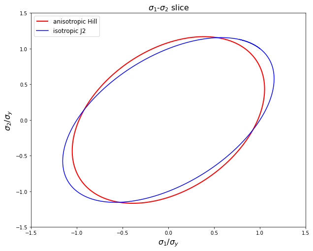

```python
import sys
if ("../source" not in sys.path):
    sys.path.append("../source")

import pyLabFEM as FE
from pyLabMaterial import Material
import numpy as np
import matplotlib.pyplot as plt
from scipy.optimize import fsolve
from sklearn.metrics import r2_score

'define two elastic-plastic materials with identical yield strength and elastic properties'
E=200.e3
nu=0.3
sy = 150.
'anistropic Hill-material as reference'
mat_h = Material(name='anisotropic Hill')
mat_h.elasticity(E=E, nu=nu)
mat_h.plasticity(sy=sy, hill=[0.7,1.,1.4], drucker=0., khard=0.)
'isotropic material for ML flow rule'
mat_ml = Material(name='ML flow rule')
mat_ml.elasticity(E=E, nu=nu)
mat_ml.plasticity(sy=sy, hill=[1.,1.,1.], drucker=0., khard=0.)
print('Yield loci of anisotropic reference material and isotropic material')
ax = mat_h.plot_yield_locus(xstart=-1.5, xend=1.5, iso=True)  #file='yield-locus-ref'
```

### Create reference stress strain curves

The mechanical behavior of the reference material in chracterized by FEA, invoking the pyLabFEM module. Four load cases are simulated: (i) uniaxial stress in x-direction, (ii) uniaxial stress in y-direction, (iii) equibiaxial tensile strain under plane stress, and (iv) pure x-y-shear strain.

```
---------------------------------------------------------
J2 yield stress under uniax-x loading: 146.385 MPa
---------------------------------------------------------
J2 yield stress under uniax-y loading: 162.698 MPa
---------------------------------------------------------
J2 yield stress under equibiax loading: 136.931 MPa
---------------------------------------------------------
J2 yield stress under shear loading: 161.126 MPa
---------------------------------------------------------
```

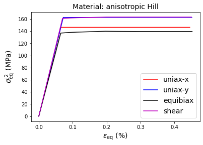

```
Hill yield stress under uniax-x loading: 150.0 MPa
---------------------------------------------------------
Hill yield stress under uniax-y loading: 150.0 MPa
---------------------------------------------------------
Hill yield stress under equibiax loading: 150.0 MPa
---------------------------------------------------------
Hill yield stress under shear loading: 150.0 MPa
---------------------------------------------------------
```

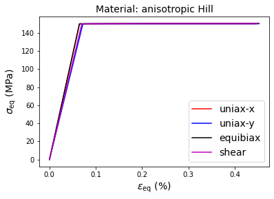

```python
'Calculate and plot stress strain curves of reference material under various load cases'
mat_h.calc_properties(verb=False, eps=0.005, sigeps=True)
mat_h.plot_stress_strain(Hill=True)  #file='sigHill-eps-ref'
```

## Setup ML constitutive models

Here, the reference material `mat_h` with Hill-type anisotropy is used to produce training and test data for the machine learning algorithm. The yield function is represented as a step function such that Support Vector Classification (SVC) is used. In the FEA all stresses are considered in form of principal stress vectors, such that a coordinate transformation into the cylindrical coordinate system with equivalent stress and polar angle $\theta$ takes place within the training and evaluation procedure. Furthermore, to make the training process efficient, stress data for training and testing are already produced as purely deviatoric stress components, following the cylidrical stress vector definition given above.

As one cannot assume the Hill-coefficients as know for the ML material, the standard J2 equivalent stresses for isotropic materials must be used in the analysis. In consequence, the yield stress must depend on the angle $\theta$ in order to discribe the anisotropy on the flow behavior. Thus, the yield function takes the form \begin{equation} f = \sigma_{eq} - \sigma_y(\theta), \end{equation} in which the dependencies on isotropic J2 equivalent stress $\sigma_{eq}$ and angle $\theta$ are separated.

### Train ML yield function

In the following code segment, training and test data are generated and applied for training of the SVC, and the quality test of the result. For the data and the trained ML yield function are plotted in the cylindrical stress space.

```
Plot theta vs. Hill eqiv. stress curves for reference material with known anisotropic coefficients
```

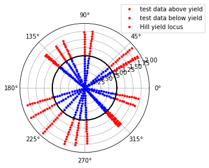

```
Using priciples stresses for training

-------------------------

SVM classification fitted
-------------------------

SVC(C=10, break_ties=False, cache_size=200, class_weight=None, coef0=0.0,
    decision_function_shape='ovr', degree=3, gamma=4.0, kernel='rbf',
    max_iter=-1, probability=False, random_state=None, shrinking=True,
    tol=0.001, verbose=False)
Training data points (only polar angle): 36 , Test data points: 20
Training set score: 99.47916666666666 %
Test set score: 99.375 %
r^2 on test data : 0.974425
Plot theta vs. J2 eqiv. stress curves for ML material
```

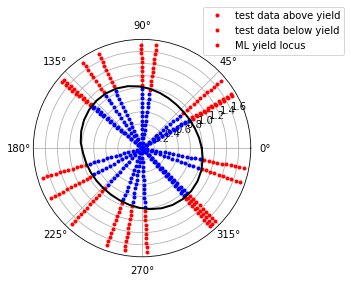

```
Plot of yield locus and training data in slices of 3D principle stress space
Plot of trained SVM classification with test data in 2D cylindrical stress space
```

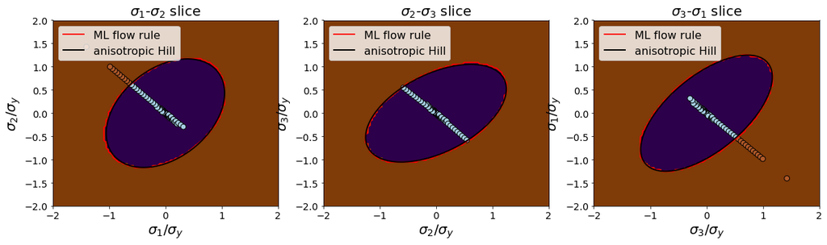

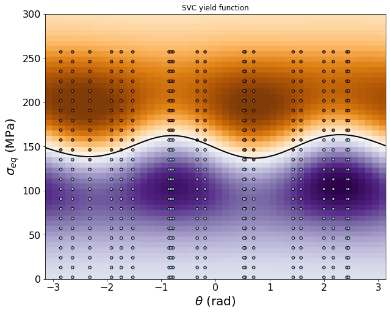

```python
'Create training data in deviatoric stress space for components seq and theta'
def create_data(N, mat, extend=False, rand=False):
    # create stresses along unit circle normal to hydrostatic axis
    if not rand:
        theta = np.linspace(-np.pi, np.pi, N)
    else:
        theta = 2.*(np.random.rand(N)-0.5)*np.pi
    sig = FE.sp_cart(np.array([np.ones(N)*np.sqrt(3/2), theta]).T)
    offs = 0.01
    x = offs*sig
    N = 23
    for i in range(N):
        hh = offs + (1.4-offs)*(i+1)/N
        x = np.append(x, hh*sig, axis=0)
    if extend:
        # add training points in plastic regime to avoid fallback of SVC decision fct. to zero
        x = np.append(x, 2.*sig, axis=0)
        x = np.append(x, 3.*sig, axis=0)
        x = np.append(x, 4.*sig, axis=0)
        x = np.append(x, 5.*sig, axis=0)
    'result data for ML yield function (only sign is considered)'
    y = np.sign(mat.calc_yf(x*mat.sy, ana=True))
    return x,y

'Training and testing data for ML yield function, based on reference Material mat_h'
ndata = 36
ntest = np.maximum(20, int(ndata/10))
x_train, y_train = create_data(ndata, mat_h, extend=True)
x_test, y_test = create_data(ntest, mat_h, rand=True)
x_train *= mat_h.sy
x_test *= mat_h.sy

print('Plot theta vs. Hill eqiv. stress curves for reference material with known anisotropic coefficients')
ind1 = np.nonzero(y_test<0.)
ind2 = np.nonzero(y_test>=0.)
sc = FE.s_cyl(x_test, mat_h)  # convert princ. stresses into cylidrical coordinates
plt.polar(sc[ind2,1],sc[ind2,0]/mat_h.sy,'.r')
plt.polar(sc[ind1,1],sc[ind1,0]/mat_h.sy,'.b')
plt.polar(np.linspace(0.,2*np.pi,36), np.ones(36), '-k', linewidth=2)
plt.legend(['test data above yield','test data below yield','Hill yield locus'], loc=(0.78,0.93))
#plt.savefig('polar-Hill.pdf', format='pdf', dpi=300)
plt.show()

'initialize and train SVC as ML yield function'
'implement ML flow rule into mat_ml'
train_sc, test_sc = mat_ml.setup_yf_SVM(x_train, y_train, x_test=x_test, y_test=y_test,
                                      C=10, gamma=4., fs=0.3, plot=False)
y_pred_clf = mat_ml.calc_yf(x_test,pred=True)
r2_score_svm = r2_score(y_test, y_pred_clf)
print('\n-------------------------\n')
print('SVM classification fitted')
print('-------------------------\n')
print(mat_ml.svm_yf)
print("Training data points (only polar angle):", ndata,", Test data points:", ntest)
print("Training set score: {} %".format(train_sc))
print("Test set score: {} %".format(test_sc))
print("r^2 on test data : %f" % r2_score_svm)

print('Plot theta vs. J2 eqiv. stress curves for ML material')
ind1 = np.nonzero(y_test<0.)
ind2 = np.nonzero(y_test>=0.)
sc = FE.s_cyl(x_test) # convert princ. stresses into cylindrical coordinates
plt.polar(sc[ind2,1],sc[ind2,0]/mat_ml.sy,'.r')
plt.polar(sc[ind1,1],sc[ind1,0]/mat_ml.sy,'.b')
'find norm of princ. stess vector lying on yield surface'
theta = np.linspace(0.,2*np.pi,36)
snorm = FE.sp_cart(np.array([mat_ml.sy*np.ones(36)*np.sqrt(3/2), theta]).T)
x1 = fsolve(mat_ml.find_yloc, np.ones(36), args=snorm, xtol=1.e-5)
sig = snorm*np.array([x1,x1,x1]).T
s_yld = mat_ml.calc_seq(sig)
plt.polar(theta, s_yld/mat_ml.sy, '-k', linewidth=2)
plt.legend(['test data above yield','test data below yield','ML yield locus'], loc=(0.78,0.93))
#plt.savefig('polar-J2.pdf', format='pdf', dpi=300)
plt.show()

print('Plot of yield locus and training data in slices of 3D principle stress space')
mat_ml.plot_yield_locus(field=True, data=x_train, ref_mat=mat_h, trange=3.e-2,
                      axis1=[0,1,2], axis2=[1,2,0]) #Nmesh=300,file='yield-fct-slices'

print('Plot of trained SVM classification with test data in 2D cylindrical stress space')
xx, yy = np.meshgrid(np.linspace(-1, 1, 50),np.linspace(-1, 1, 50))
fig, ax  = plt.subplots(nrows=1, ncols=1, figsize=(10,8))
feat = np.c_[yy.ravel(),xx.ravel()]
#Z = mat_ml.svm_yf.predict(feat)
Z = mat_ml.svm_yf.decision_function(feat)
hl = mat_ml.plot_data(Z, ax, xx*np.pi, (yy+1.)*mat_ml.sy, c='black')
sc = FE.s_cyl(x_test)
h1 = ax.scatter(sc[:,1], sc[:,0], s=20, c=y_test, cmap=plt.cm.Paired, edgecolors='k')
ax.set_title('SVC yield function')
ax.set_xlabel(r'$\theta$ (rad)', fontsize=20)
ax.set_ylabel(r'$\sigma_{eq}$ (MPa)', fontsize=20)
ax.tick_params(axis="x", labelsize=16)
ax.tick_params(axis="y", labelsize=16)
#fig.savefig('SVM-yield-fct.pdf', format='pdf', dpi=300)
```

### Apply trained ML flow rule in FEA

After the successful training of the ML yield function, it can be applied directly in FEA. Its gradients of can be calculated directly from the coefficients and the support vectors resulting from the training process. The following code segment, demonstrates the application of the ML yield function in the pyLabFEA module. First, a model with two sections is generates, where section 1 is assigned to the reference material `mat_h` and section 2 is assigned to `mat_ml` with the ML yield function.

```
==========================================
=== FEA with reference and ML material ===
==========================================
Global strain:  [-0.0017  0.004  -0.001   0.      0.     -0.    ]
Element strain (ref):  [-0.0016  0.004  -0.001   0.      0.     -0.    ]
Element strain (ML):  [-0.0018  0.004  -0.0009  0.      0.     -0.    ]
Global stress:  [  0.     162.6389   0.       0.       0.      -0.    ]
Element stress (ref):  [  0.     162.6389   0.       0.       0.      -0.    ]
Element stress (ML):  [  0.     162.6389   0.       0.       0.      -0.    ]
Global plastic strain:  [-0.00143  0.00319 -0.00175  0.       0.       0.     ]
Plastic strain (ref):  [-0.00131  0.00319 -0.00187  0.       0.       0.     ]
Plastic strain (ML):  [-0.00155  0.00319 -0.00163  0.       0.       0.     ]
----------------------------
Material 1 (left block):   {'yield_fct': 'analytical', 'gradient': 'analytical'}
Material 2 (right block):  {'yield_fct': 'ML_yf-decision-fct', 'gradient': 'gradient to ML_yf'}
```

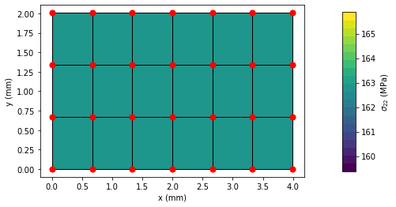

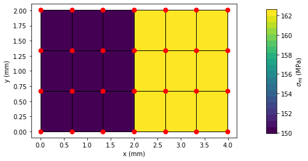

```
Note: Different definitions of SEQ for Hill and J2.
```

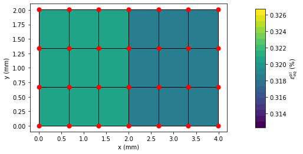

```python
fem=FE.Model(dim=2,planestress=True)
fem.geom([2, 2], LY=2.)  # define sections in absolute lengths
print('==========================================')
print('=== FEA with reference and ML material ===')
print('==========================================')
fem.assign([mat_h, mat_ml])  # create a model with trained ML-flow rule (mat_h) and reference material (mat3)
fem.bcleft(0.)
fem.bcbot(0.)
fem.bcright(0., 'force')   # free right edge
fem.bctop(0.004*fem.leny, 'disp')  # apply displacement at top nodes (uniax y-stress)
fem.mesh(NX=6, NY=3)
fem.solve()
fem.calc_global()
print('Global strain: ', np.round(fem.glob['eps'],decimals=4))
print('Element strain (ref): ', np.round(fem.element[0].eps,decimals=4))
print('Element strain (ML): ', np.round(fem.element[10].eps,decimals=4))
print('Global stress: ', np.round(fem.glob['sig'],decimals=4))
print('Element stress (ref): ', np.round(fem.element[0].sig,decimals=4))
print('Element stress (ML): ', np.round(fem.element[10].sig,decimals=4))
print('Global plastic strain: ', np.round(fem.glob['epl'],decimals=5))
print('Plastic strain (ref): ', np.round(fem.element[0].epl,decimals=5))
print('Plastic strain (ML): ', np.round(fem.element[10].epl,decimals=5))
print('----------------------------')
print('Material 1 (left block):  ',mat_h.msg)
print('Material 2 (right block): ',mat_ml.msg)

fem.plot('stress2',mag=1)
fem.plot('seq',mag=1)
print('Note: Different definitions of SEQ for Hill and J2.')
fem.plot('peeq',mag=1)
```

Note that the element stresses in both materials are very similar (top figure). However, the different definitions of the Hill equivalent stress and the J2 equivalent stress produce a numerical difference in the plot of the equivalent stresses (middle figure). The resulting plastic strains in both sections are quite similar (bottom figure).

The second example applies the same four load cases under which the reference material has been characterized and compares the results.

```
====== Stress-Strain-Curves ======
---------------------------------------------------------
J2 yield stress under uniax-x loading: 148.35 MPa
---------------------------------------------------------
J2 yield stress under uniax-y loading: 162.408 MPa
---------------------------------------------------------
J2 yield stress under equibiax loading: 139.51 MPa
---------------------------------------------------------
J2 yield stress under shear loading: 161.128 MPa
---------------------------------------------------------
```

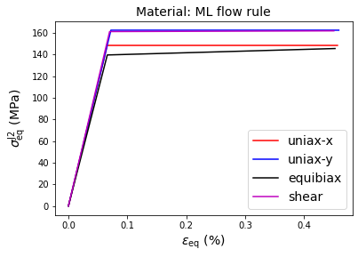

```
*** load case:  uniax-x
             Rel. error in yield strength :  1.342 %
Rel. error in plastic strain at max. load :  -1.938 %
*** load case:  uniax-y
             Rel. error in yield strength :  -0.178 %
Rel. error in plastic strain at max. load :  -0.47 %
*** load case:  equibiax
             Rel. error in yield strength :  1.883 %
Rel. error in plastic strain at max. load :  -0.25 %
*** load case:  shear
             Rel. error in yield strength :  0.001 %
Rel. error in plastic strain at max. load :  0.121 %

Plot evolution of stresses during plastic deformation for both materials
Hill-material: blue/cyan colors
ML-material: yellow/green colors
```

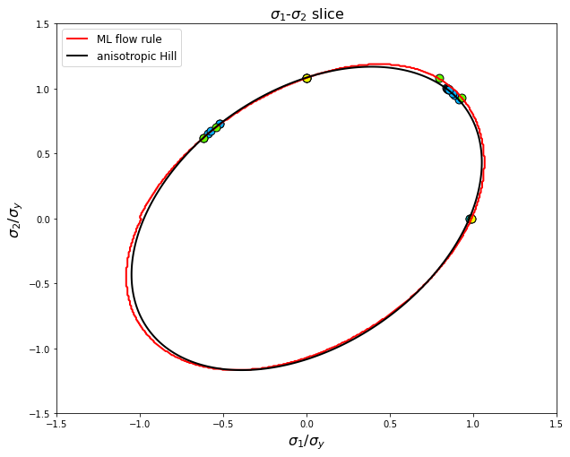

```python
print('\n\n====== Stress-Strain-Curves ======')
mat_ml.calc_properties(verb=False, eps=0.005, sigeps=True)
mat_ml.plot_stress_strain()  # file='sigJ2-eps-ML'
for sel in mat_h.prop:
    hh = mat_ml.propJ2[sel]['ys']/mat_h.propJ2[sel]['ys'] - 1.
    print('*** load case: ',mat_h.prop[sel]['name'])
    print('             Rel. error in yield strength : ', np.round(100*hh, decimals=3),'%')
    hh = np.amax(mat_ml.propJ2[sel]['peeq'])/np.amax(mat_h.propJ2[sel]['peeq']) - 1.
    print('Rel. error in plastic strain at max. load : ', np.round(100*hh,decimals=3),'%')

'plot yield locus'
ax = mat_ml.plot_yield_locus(xstart=-1.5, xend=1.5, ref_mat=mat_h, field=False, Nmesh=400)
print('\nPlot evolution of stresses during plastic deformation for both materials')
print('Hill-material: blue/cyan colors')
print('ML-material: yellow/green colors')
s=80
'Hill material'
stx = mat_h.sigeps['stx']['sig'][:,0:2]/mat_h.sy
sty = mat_h.sigeps['sty']['sig'][:,0:2]/mat_h.sy
et2 = mat_h.sigeps['et2']['sig'][:,0:2]/mat_h.sy
ect = mat_h.sigeps['ect']['sig'][:,0:2]/mat_h.sy
ax.scatter(stx[1:,0],stx[1:,1],s=s, c='#00faff', edgecolors='k')
ax.scatter(sty[1:,0],sty[1:,1],s=s, c='#00faff', edgecolors='k')
ax.scatter(et2[1:,0],et2[1:,1],s=s, c='#00b0ff', edgecolors='k')
ax.scatter(ect[1:,0],ect[1:,1],s=s, c='#00b0ff', edgecolors='k')
'ML material'
stx = mat_ml.sigeps['stx']['sig'][:,0:2]/mat_h.sy
sty = mat_ml.sigeps['sty']['sig'][:,0:2]/mat_h.sy
et2 = mat_ml.sigeps['et2']['sig'][:,0:2]/mat_h.sy
ect = mat_ml.sigeps['ect']['sig'][:,0:2]/mat_h.sy
ax.scatter(stx[1:,0],stx[1:,1],s=s, c='#f0ff00', edgecolors='k')
ax.scatter(sty[1:,0],sty[1:,1],s=s, c='#f0ff00', edgecolors='k')
ax.scatter(et2[1:,0],et2[1:,1],s=s, c='#60ff00', edgecolors='k')
ax.scatter(ect[1:,0],ect[1:,1],s=s, c='#60ff00', edgecolors='k')
```

## Train ML yield function with results of 4 load cases

In the following, the training data is created only from the four load cases of the reference material. For all load cases $\sigma_3=0$, yet due to the data-oriented formulation of the yield function on the deviatoric plane, a full yield function can be achieved. A new material `mat3` is created on which the ML training is performed.

```
Plot theta vs. J2 eqiv. stress curves for ML material
```

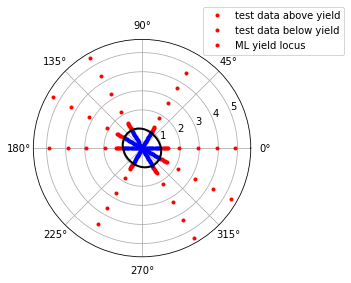

```
Using priciples stresses for training

-------------------------

SVM classification fitted
-------------------------

SVC(C=10, break_ties=False, cache_size=200, class_weight=None, coef0=0.0,
    decision_function_shape='ovr', degree=3, gamma=4.0, kernel='rbf',
    max_iter=-1, probability=False, random_state=None, shrinking=True,
    tol=0.001, verbose=False)
Training data points (only polar angle): 36 , Test data points: 20
Training set score: 99.28571428571429 %
Test set score: 99.375 %
r^2 on test data : 0.974425
Plot of yield locus and training data in slices of 3D principle stress space
```

```
array([<matplotlib.axes._subplots.AxesSubplot object at 0x1a1e812310>,
      dtype=object)
```

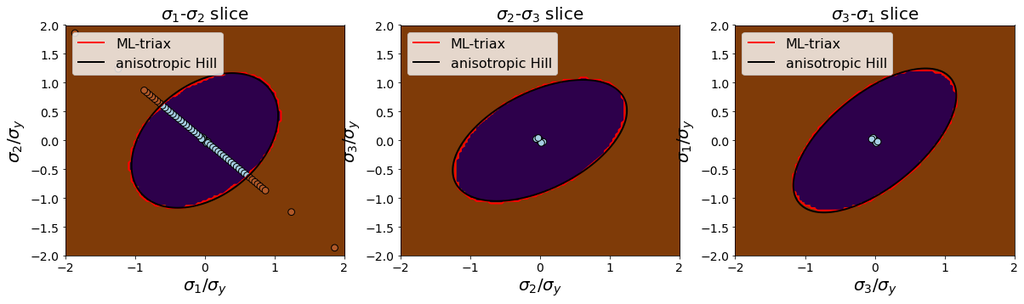

```python
'get principle yield stresses of 4 load cases from reference material'
sig=np.zeros((4,3))
i=0
for sel in mat_h.sigeps:
    peeq = FE.eps_eq(mat_h.sigeps[sel]['epl'])
    iys = np.nonzero(peeq<1.e-6)  # take stress at last index of elastic regime
    ys = mat_h.sigeps[sel]['sig']
    sp_yld = FE.Stress(ys[iys[0][-1]]).p
    sig[i,:] = sp_yld
    i += 1

'mirror data in theta space: tension-compression symmetry'
sc1 = FE.s_cyl(sig)
sc2 = np.zeros((4,3))
sc2[:,0] = sc1[:,0]
sc2[:,1] = sc1[:,1]-np.pi
sc2[:,2] = sc1[:,2]
sc = np.append(sc1,sc2,axis=0)
sig = FE.sp_cart(sc)

'expand stresses into elastic and plastic regimes'
offs = 0.01
x = offs*sig
N = 23
for i in range(N):
    hh = offs + (1.4-offs)*(i+1)/N
    x = np.append(x, hh*sig, axis=0)
# add training points in plastic regime to avoid fallback of SVC decision fct. to zero
x = np.append(x, 2.*sig, axis=0)
x = np.append(x, 3.*sig, axis=0)
x = np.append(x, 4.*sig, axis=0)
x = np.append(x, 5.*sig, axis=0)

'result data for training of ML yield function'
y = mat_ml.calc_yf(x, pred=True)

print('Plot theta vs. J2 eqiv. stress curves for ML material')
ind1 = np.nonzero(y<0.)
ind2 = np.nonzero(y>=0.)
sc = FE.s_cyl(x) # convert princ. stresses into cylindrical coordinates
plt.polar(sc[ind2,1],sc[ind2,0]/mat_ml.sy,'.r')
plt.polar(sc[ind1,1],sc[ind1,0]/mat_ml.sy,'.b')
'find norm of princ. stess vector lying on yield surface'
theta = np.linspace(0.,2*np.pi,36)
snorm = FE.sp_cart(np.array([mat_ml.sy*np.ones(36)*np.sqrt(3/2), theta]).T)
x1 = fsolve(mat_ml.find_yloc, np.ones(36), args=snorm, xtol=1.e-5)
hs = snorm*np.array([x1,x1,x1]).T
s_yld = mat_ml.calc_seq(hs)
plt.polar(theta, s_yld/mat_ml.sy, '-k', linewidth=2)
plt.legend(['test data above yield','test data below yield','ML yield locus'], loc=(0.78,0.93))
#plt.savefig('polar-J2.pdf', format='pdf', dpi=300)
plt.show()

'define material for training with new data'
mat3 = Material(name='ML-triax')
mat3.elasticity(E=E, nu=nu)
mat3.plasticity(sy=mat_h.sy, hill=[1., 1., 1.], drucker=0., khard=0.)

'initialize and train SVC as yield function'
train_sc, test_sc = mat3.setup_yf_SVM(x, y, x_test=x_test, y_test=y_test,
                                      C=10, gamma=4., fs=0.3, plot=False)
y_pred_clf = mat3.calc_yf(x_test,pred=True)
r2_score_svm = r2_score(y_test, y_pred_clf)
print('\n-------------------------\n')
print('SVM classification fitted')
print('-------------------------\n')
print(mat3.svm_yf)
print("Training data points (only polar angle):", ndata,", Test data points:", ntest)
print("Training set score: {} %".format(train_sc))
print("Test set score: {} %".format(test_sc))
print("r^2 on test data : %f" % r2_score_svm)

print('Plot of yield locus and training data in slices of 3D principle stress space')
mat3.plot_yield_locus(ref_mat=mat_h, data=x, field=True,
                      trange=3.e-2, axis1=[0,1,2], axis2=[1,2,0]) #Nmesh=300,file='yield-fct-slices'
```